# wrangle_act

```python
import pandas as pd
import numpy as np
import requests
import tweepy
import json
import re
import matplotlib.pyplot as plt
import warnings
```

## Gather

```python
# Read in csv file as a Pandas DataFrame
twitter_archive = pd.read_csv('twitter-archive-enhanced.csv')
```

```python
# Use requests library to download tsv file from a website
url="https://d17h27t6h515a5.cloudfront.net/topher/2017/August/599fd2ad_image-predictions/image-predictions.tsv"
response = requests.get(url)

with open('image_predictions.tsv', 'wb') as file:
    file.write(response.content)

# Read in tsv file as a Pandas DataFrame
image_predictions = pd.read_csv('image_predictions.tsv', sep='\t')
```

```python
# Personal API keys, secrets, and tokens have been replaced with placeholders
consumer_key = 'MY CONSUMER KEY'
consumer_secret = 'MY CONSUMER SECRET'
access_token = 'MY ACCESS TOKEN'
access_secret = 'MY ACCESS SECRET'
```

```python
# Variables created for tweepy query
auth = tweepy.OAuthHandler(consumer_key, consumer_secret)
auth.set_access_token(access_token, access_secret)
api = tweepy.API(auth, wait_on_rate_limit = True, wait_on_rate_limit_notify = True)
```

```python
# For loop which will add each available tweet to a new line of tweet_json.txt
with open('tweet_json.txt', 'a', encoding='utf8') as f:
    for tweet_id in twitter_archive['tweet_id']:
        try:
            tweet = api.get_status(tweet_id, tweet_mode='extended')
            json.dump(tweet._json, f)
            f.write('\n')
        except:
            continue
```

```
Rate limit reached. Sleeping for: 733
Rate limit reached. Sleeping for: 729
```

```python
# For loop to append each tweet into a list
tweets_data = []

tweet_file = open('tweet_json.txt', "r")

for line in tweet_file:
    try:
        tweet = json.loads(line)
        tweets_data.append(tweet)
    except:
        continue

tweet_file.close()
```

```python
# Create tweet_info DataFrame
tweet_info = pd.DataFrame()
```

```python
# Add selected variables to tweet_info DataFrame
tweet_info['id'] = list(map(lambda tweet: tweet['id'], tweets_data))
tweet_info['retweet_count'] = list(map(lambda tweet: tweet['retweet_count'], tweets_data))
tweet_info['favorite_count'] = list(map(lambda tweet: tweet['favorite_count'], tweets_data))
```

## Assess

```python
# View first 20 rows of twitter_archive DataFrame
twitter_archive.head(20)
```

|  | tweet_id | in_reply_to_status_id | in_reply_to_user_id | timestamp | source | text | retweeted_status_id | retweeted_status_user_id | retweeted_status_timestamp | expanded_urls | rating_numerator | rating_denominator | name | doggo | floofer | pupper | puppo |
| --- | --- | --- | --- | --- | --- | --- | --- | --- | --- | --- | --- | --- | --- | --- | --- | --- | --- |
| 0 | 892420643555336193 | NaN | NaN | 2017-08-01 16:23:56 +0000 | <a href="http://twitter.com/download/iphone" r... | This is Phineas. He's a mystical boy. Only eve... | NaN | NaN | NaN | https://twitter.com/dog_rates/status/892420643... | 13 | 10 | Phineas | None | None | None | None |
| 1 | 892177421306343426 | NaN | NaN | 2017-08-01 00:17:27 +0000 | <a href="http://twitter.com/download/iphone" r... | This is Tilly. She's just checking pup on you.... | NaN | NaN | NaN | https://twitter.com/dog_rates/status/892177421... | 13 | 10 | Tilly | None | None | None | None |
| 2 | 891815181378084864 | NaN | NaN | 2017-07-31 00:18:03 +0000 | <a href="http://twitter.com/download/iphone" r... | This is Archie. He is a rare Norwegian Pouncin... | NaN | NaN | NaN | https://twitter.com/dog_rates/status/891815181... | 12 | 10 | Archie | None | None | None | None |
| 3 | 891689557279858688 | NaN | NaN | 2017-07-30 15:58:51 +0000 | <a href="http://twitter.com/download/iphone" r... | This is Darla. She commenced a snooze mid meal... | NaN | NaN | NaN | https://twitter.com/dog_rates/status/891689557... | 13 | 10 | Darla | None | None | None | None |
| 4 | 891327558926688256 | NaN | NaN | 2017-07-29 16:00:24 +0000 | <a href="http://twitter.com/download/iphone" r... | This is Franklin. He would like you to stop ca... | NaN | NaN | NaN | https://twitter.com/dog_rates/status/891327558... | 12 | 10 | Franklin | None | None | None | None |
| 5 | 891087950875897856 | NaN | NaN | 2017-07-29 00:08:17 +0000 | <a href="http://twitter.com/download/iphone" r... | Here we have a majestic great white breaching ... | NaN | NaN | NaN | https://twitter.com/dog_rates/status/891087950... | 13 | 10 | None | None | None | None | None |
| 6 | 890971913173991426 | NaN | NaN | 2017-07-28 16:27:12 +0000 | <a href="http://twitter.com/download/iphone" r... | Meet Jax. He enjoys ice cream so much he gets ... | NaN | NaN | NaN | https://gofundme.com/ydvmve-surgery-for-jax,ht... | 13 | 10 | Jax | None | None | None | None |
| 7 | 890729181411237888 | NaN | NaN | 2017-07-28 00:22:40 +0000 | <a href="http://twitter.com/download/iphone" r... | When you watch your owner call another dog a g... | NaN | NaN | NaN | https://twitter.com/dog_rates/status/890729181... | 13 | 10 | None | None | None | None | None |
| 8 | 890609185150312448 | NaN | NaN | 2017-07-27 16:25:51 +0000 | <a href="http://twitter.com/download/iphone" r... | This is Zoey. She doesn't want to be one of th... | NaN | NaN | NaN | https://twitter.com/dog_rates/status/890609185... | 13 | 10 | Zoey | None | None | None | None |
| 9 | 890240255349198849 | NaN | NaN | 2017-07-26 15:59:51 +0000 | <a href="http://twitter.com/download/iphone" r... | This is Cassie. She is a college pup. Studying... | NaN | NaN | NaN | https://twitter.com/dog_rates/status/890240255... | 14 | 10 | Cassie | doggo | None | None | None |
| 10 | 890006608113172480 | NaN | NaN | 2017-07-26 00:31:25 +0000 | <a href="http://twitter.com/download/iphone" r... | This is Koda. He is a South Australian decksha... | NaN | NaN | NaN | https://twitter.com/dog_rates/status/890006608... | 13 | 10 | Koda | None | None | None | None |
| 11 | 889880896479866881 | NaN | NaN | 2017-07-25 16:11:53 +0000 | <a href="http://twitter.com/download/iphone" r... | This is Bruno. He is a service shark. Only get... | NaN | NaN | NaN | https://twitter.com/dog_rates/status/889880896... | 13 | 10 | Bruno | None | None | None | None |
| 12 | 889665388333682689 | NaN | NaN | 2017-07-25 01:55:32 +0000 | <a href="http://twitter.com/download/iphone" r... | Here's a puppo that seems to be on the fence a... | NaN | NaN | NaN | https://twitter.com/dog_rates/status/889665388... | 13 | 10 | None | None | None | None | puppo |
| 13 | 889638837579907072 | NaN | NaN | 2017-07-25 00:10:02 +0000 | <a href="http://twitter.com/download/iphone" r... | This is Ted. He does his best. Sometimes that'... | NaN | NaN | NaN | https://twitter.com/dog_rates/status/889638837... | 12 | 10 | Ted | None | None | None | None |
| 14 | 889531135344209921 | NaN | NaN | 2017-07-24 17:02:04 +0000 | <a href="http://twitter.com/download/iphone" r... | This is Stuart. He's sporting his favorite fan... | NaN | NaN | NaN | https://twitter.com/dog_rates/status/889531135... | 13 | 10 | Stuart | None | None | None | puppo |
| 15 | 889278841981685760 | NaN | NaN | 2017-07-24 00:19:32 +0000 | <a href="http://twitter.com/download/iphone" r... | This is Oliver. You're witnessing one of his m... | NaN | NaN | NaN | https://twitter.com/dog_rates/status/889278841... | 13 | 10 | Oliver | None | None | None | None |
| 16 | 888917238123831296 | NaN | NaN | 2017-07-23 00:22:39 +0000 | <a href="http://twitter.com/download/iphone" r... | This is Jim. He found a fren. Taught him how t... | NaN | NaN | NaN | https://twitter.com/dog_rates/status/888917238... | 12 | 10 | Jim | None | None | None | None |
| 17 | 888804989199671297 | NaN | NaN | 2017-07-22 16:56:37 +0000 | <a href="http://twitter.com/download/iphone" r... | This is Zeke. He has a new stick. Very proud o... | NaN | NaN | NaN | https://twitter.com/dog_rates/status/888804989... | 13 | 10 | Zeke | None | None | None | None |
| 18 | 888554962724278272 | NaN | NaN | 2017-07-22 00:23:06 +0000 | <a href="http://twitter.com/download/iphone" r... | This is Ralphus. He's powering up. Attempting ... | NaN | NaN | NaN | https://twitter.com/dog_rates/status/888554962... | 13 | 10 | Ralphus | None | None | None | None |
| 19 | 888202515573088257 | NaN | NaN | 2017-07-21 01:02:36 +0000 | <a href="http://twitter.com/download/iphone" r... | RT @dog_rates: This is Canela. She attempted s... | 8.874740e+17 | 4.196984e+09 | 2017-07-19 00:47:34 +0000 | https://twitter.com/dog_rates/status/887473957... | 13 | 10 | Canela | None | None | None | None |

```python
# View last 5 rows of twitter_archive DataFrame
twitter_archive.tail()
```

|  | tweet_id | in_reply_to_status_id | in_reply_to_user_id | timestamp | source | text | retweeted_status_id | retweeted_status_user_id | retweeted_status_timestamp | expanded_urls | rating_numerator | rating_denominator | name | doggo | floofer | pupper | puppo |
| --- | --- | --- | --- | --- | --- | --- | --- | --- | --- | --- | --- | --- | --- | --- | --- | --- | --- |
| 2351 | 666049248165822465 | NaN | NaN | 2015-11-16 00:24:50 +0000 | <a href="http://twitter.com/download/iphone" r... | Here we have a 1949 1st generation vulpix. Enj... | NaN | NaN | NaN | https://twitter.com/dog_rates/status/666049248... | 5 | 10 | None | None | None | None | None |
| 2352 | 666044226329800704 | NaN | NaN | 2015-11-16 00:04:52 +0000 | <a href="http://twitter.com/download/iphone" r... | This is a purebred Piers Morgan. Loves to Netf... | NaN | NaN | NaN | https://twitter.com/dog_rates/status/666044226... | 6 | 10 | a | None | None | None | None |
| 2353 | 666033412701032449 | NaN | NaN | 2015-11-15 23:21:54 +0000 | <a href="http://twitter.com/download/iphone" r... | Here is a very happy pup. Big fan of well-main... | NaN | NaN | NaN | https://twitter.com/dog_rates/status/666033412... | 9 | 10 | a | None | None | None | None |
| 2354 | 666029285002620928 | NaN | NaN | 2015-11-15 23:05:30 +0000 | <a href="http://twitter.com/download/iphone" r... | This is a western brown Mitsubishi terrier. Up... | NaN | NaN | NaN | https://twitter.com/dog_rates/status/666029285... | 7 | 10 | a | None | None | None | None |
| 2355 | 666020888022790149 | NaN | NaN | 2015-11-15 22:32:08 +0000 | <a href="http://twitter.com/download/iphone" r... | Here we have a Japanese Irish Setter. Lost eye... | NaN | NaN | NaN | https://twitter.com/dog_rates/status/666020888... | 8 | 10 | None | None | None | None | None |

```python
# View info of twitter_archive DataFrame
twitter_archive.info()
```

```
<class 'pandas.core.frame.DataFrame'>
RangeIndex: 2356 entries, 0 to 2355
Data columns (total 17 columns):
tweet_id                      2356 non-null int64
in_reply_to_status_id         78 non-null float64
in_reply_to_user_id           78 non-null float64
timestamp                     2356 non-null object
source                        2356 non-null object
text                          2356 non-null object
retweeted_status_id           181 non-null float64
retweeted_status_user_id      181 non-null float64
retweeted_status_timestamp    181 non-null object
expanded_urls                 2297 non-null object
rating_numerator              2356 non-null int64
rating_denominator            2356 non-null int64
name                          2356 non-null object
doggo                         2356 non-null object
floofer                       2356 non-null object
pupper                        2356 non-null object
puppo                         2356 non-null object
dtypes: float64(4), int64(3), object(10)
memory usage: 313.0+ KB
```

```python
# View descriptive statistics of twitter_archive DataFrame
twitter_archive.describe()
```

|  | tweet_id | in_reply_to_status_id | in_reply_to_user_id | retweeted_status_id | retweeted_status_user_id | rating_numerator | rating_denominator |
| --- | --- | --- | --- | --- | --- | --- | --- |
| count | 2.356000e+03 | 7.800000e+01 | 7.800000e+01 | 1.810000e+02 | 1.810000e+02 | 2356.000000 | 2356.000000 |
| mean | 7.427716e+17 | 7.455079e+17 | 2.014171e+16 | 7.720400e+17 | 1.241698e+16 | 13.126486 | 10.455433 |
| std | 6.856705e+16 | 7.582492e+16 | 1.252797e+17 | 6.236928e+16 | 9.599254e+16 | 45.876648 | 6.745237 |
| min | 6.660209e+17 | 6.658147e+17 | 1.185634e+07 | 6.661041e+17 | 7.832140e+05 | 0.000000 | 0.000000 |
| 25% | 6.783989e+17 | 6.757419e+17 | 3.086374e+08 | 7.186315e+17 | 4.196984e+09 | 10.000000 | 10.000000 |
| 50% | 7.196279e+17 | 7.038708e+17 | 4.196984e+09 | 7.804657e+17 | 4.196984e+09 | 11.000000 | 10.000000 |
| 75% | 7.993373e+17 | 8.257804e+17 | 4.196984e+09 | 8.203146e+17 | 4.196984e+09 | 12.000000 | 10.000000 |
| max | 8.924206e+17 | 8.862664e+17 | 8.405479e+17 | 8.874740e+17 | 7.874618e+17 | 1776.000000 | 170.000000 |

```python
# View first 5 rows of image_predictions DataFrame
image_predictions.head()
```

|  | tweet_id | jpg_url | img_num | p1 | p1_conf | p1_dog | p2 | p2_conf | p2_dog | p3 | p3_conf | p3_dog |
| --- | --- | --- | --- | --- | --- | --- | --- | --- | --- | --- | --- | --- |
| 0 | 666020888022790149 | https://pbs.twimg.com/media/CT4udn0WwAA0aMy.jpg | 1 | Welsh_springer_spaniel | 0.465074 | True | collie | 0.156665 | True | Shetland_sheepdog | 0.061428 | True |
| 1 | 666029285002620928 | https://pbs.twimg.com/media/CT42GRgUYAA5iDo.jpg | 1 | redbone | 0.506826 | True | miniature_pinscher | 0.074192 | True | Rhodesian_ridgeback | 0.072010 | True |
| 2 | 666033412701032449 | https://pbs.twimg.com/media/CT4521TWwAEvMyu.jpg | 1 | German_shepherd | 0.596461 | True | malinois | 0.138584 | True | bloodhound | 0.116197 | True |
| 3 | 666044226329800704 | https://pbs.twimg.com/media/CT5Dr8HUEAA-lEu.jpg | 1 | Rhodesian_ridgeback | 0.408143 | True | redbone | 0.360687 | True | miniature_pinscher | 0.222752 | True |
| 4 | 666049248165822465 | https://pbs.twimg.com/media/CT5IQmsXIAAKY4A.jpg | 1 | miniature_pinscher | 0.560311 | True | Rottweiler | 0.243682 | True | Doberman | 0.154629 | True |

```python
# View last 5 rows of image_predictions DataFrame
image_predictions.tail()
```

|  | tweet_id | jpg_url | img_num | p1 | p1_conf | p1_dog | p2 | p2_conf | p2_dog | p3 | p3_conf | p3_dog |
| --- | --- | --- | --- | --- | --- | --- | --- | --- | --- | --- | --- | --- |
| 2070 | 891327558926688256 | https://pbs.twimg.com/media/DF6hr6BUMAAzZgT.jpg | 2 | basset | 0.555712 | True | English_springer | 0.225770 | True | German_short-haired_pointer | 0.175219 | True |
| 2071 | 891689557279858688 | https://pbs.twimg.com/media/DF_q7IAWsAEuuN8.jpg | 1 | paper_towel | 0.170278 | False | Labrador_retriever | 0.168086 | True | spatula | 0.040836 | False |
| 2072 | 891815181378084864 | https://pbs.twimg.com/media/DGBdLU1WsAANxJ9.jpg | 1 | Chihuahua | 0.716012 | True | malamute | 0.078253 | True | kelpie | 0.031379 | True |
| 2073 | 892177421306343426 | https://pbs.twimg.com/media/DGGmoV4XsAAUL6n.jpg | 1 | Chihuahua | 0.323581 | True | Pekinese | 0.090647 | True | papillon | 0.068957 | True |
| 2074 | 892420643555336193 | https://pbs.twimg.com/media/DGKD1-bXoAAIAUK.jpg | 1 | orange | 0.097049 | False | bagel | 0.085851 | False | banana | 0.076110 | False |

```python
# View info of image_predictions DataFrame
image_predictions.info()
```

```
<class 'pandas.core.frame.DataFrame'>
RangeIndex: 2075 entries, 0 to 2074
Data columns (total 12 columns):
tweet_id    2075 non-null int64
jpg_url     2075 non-null object
img_num     2075 non-null int64
p1          2075 non-null object
p1_conf     2075 non-null float64
p1_dog      2075 non-null bool
p2          2075 non-null object
p2_conf     2075 non-null float64
p2_dog      2075 non-null bool
p3          2075 non-null object
p3_conf     2075 non-null float64
p3_dog      2075 non-null bool
dtypes: bool(3), float64(3), int64(2), object(4)
memory usage: 152.1+ KB
```

```python
# View descriptive statistics of image_predictions DataFrame
image_predictions.describe()
```

|  | tweet_id | img_num | p1_conf | p2_conf | p3_conf |
| --- | --- | --- | --- | --- | --- |
| count | 2.075000e+03 | 2075.000000 | 2075.000000 | 2.075000e+03 | 2.075000e+03 |
| mean | 7.384514e+17 | 1.203855 | 0.594548 | 1.345886e-01 | 6.032417e-02 |
| std | 6.785203e+16 | 0.561875 | 0.271174 | 1.006657e-01 | 5.090593e-02 |
| min | 6.660209e+17 | 1.000000 | 0.044333 | 1.011300e-08 | 1.740170e-10 |
| 25% | 6.764835e+17 | 1.000000 | 0.364412 | 5.388625e-02 | 1.622240e-02 |
| 50% | 7.119988e+17 | 1.000000 | 0.588230 | 1.181810e-01 | 4.944380e-02 |
| 75% | 7.932034e+17 | 1.000000 | 0.843855 | 1.955655e-01 | 9.180755e-02 |
| max | 8.924206e+17 | 4.000000 | 1.000000 | 4.880140e-01 | 2.734190e-01 |

```python
# View first 5 rows of tweet_info DataFrame
tweet_info.head()
```

|  | id | retweet_count | favorite_count |
| --- | --- | --- | --- |
| 0 | 892420643555336193 | 8773 | 39292 |
| 1 | 892177421306343426 | 6426 | 33648 |
| 2 | 891815181378084864 | 4268 | 25342 |
| 3 | 891689557279858688 | 8858 | 42663 |
| 4 | 891327558926688256 | 9639 | 40809 |

- Join 'tweet_info' to 'twitter_archive'

```python
# View last 5 rows of tweet_info DataFrame
tweet_info.tail()
```

|  | id | retweet_count | favorite_count |
| --- | --- | --- | --- |
| 2344 | 666049248165822465 | 40 | 110 |
| 2345 | 666044226329800704 | 143 | 306 |
| 2346 | 666033412701032449 | 46 | 127 |
| 2347 | 666029285002620928 | 47 | 131 |
| 2348 | 666020888022790149 | 527 | 2528 |

```python
# View info of tweet_info DataFrame
tweet_info.info()
```

```
<class 'pandas.core.frame.DataFrame'>
RangeIndex: 2349 entries, 0 to 2348
Data columns (total 3 columns):
id                2349 non-null int64
retweet_count     2349 non-null int64
favorite_count    2349 non-null int64
dtypes: int64(3)
memory usage: 55.1 KB
```

```python
# View descriptive statistics of tweet_info DataFrame
tweet_info.describe()
```

|  | id | retweet_count | favorite_count |
| --- | --- | --- | --- |
| count | 2.349000e+03 | 2349.000000 | 2349.000000 |
| mean | 7.424674e+17 | 3093.778203 | 8107.251596 |
| std | 6.840987e+16 | 5128.512600 | 12057.756736 |
| min | 6.660209e+17 | 0.000000 | 0.000000 |
| 25% | 6.783890e+17 | 615.000000 | 1413.000000 |
| 50% | 7.193325e+17 | 1443.000000 | 3585.000000 |
| 75% | 7.989257e+17 | 3600.000000 | 10090.000000 |
| max | 8.924206e+17 | 78668.000000 | 131704.000000 |

```python
# View rows in twitter_archive which contain '&amp;' instead of '&' in 'text' column
twitter_archive[twitter_archive.text.str.contains('&amp;')]
```

|  | tweet_id | in_reply_to_status_id | in_reply_to_user_id | timestamp | source | text | retweeted_status_id | retweeted_status_user_id | retweeted_status_timestamp | expanded_urls | rating_numerator | rating_denominator | name | doggo | floofer | pupper | puppo |
| --- | --- | --- | --- | --- | --- | --- | --- | --- | --- | --- | --- | --- | --- | --- | --- | --- | --- |
| 262 | 842765311967449089 | NaN | NaN | 2017-03-17 15:51:22 +0000 | <a href="http://twitter.com/download/iphone" r... | Meet Indie. She's not a fan of baths but she's... | NaN | NaN | NaN | https://www.gofundme.com/get-indie-home/,https... | 12 | 10 | Indie | None | None | None | None |
| 273 | 840728873075638272 | NaN | NaN | 2017-03-12 00:59:17 +0000 | <a href="http://twitter.com/download/iphone" r... | RT @dog_rates: This is Pipsy. He is a fluffbal... | 6.671522e+17 | 4.196984e+09 | 2015-11-19 01:27:25 +0000 | https://twitter.com/dog_rates/status/667152164... | 12 | 10 | Pipsy | None | None | None | None |
| 320 | 834458053273591808 | NaN | NaN | 2017-02-22 17:41:18 +0000 | <a href="http://twitter.com/download/iphone" r... | Meet Chester (bottom) &amp; Harold (top). They... | NaN | NaN | NaN | https://twitter.com/dog_rates/status/834458053... | 12 | 10 | Chester | None | None | None | None |
| 461 | 817536400337801217 | NaN | NaN | 2017-01-07 01:00:41 +0000 | <a href="http://twitter.com/download/iphone" r... | Say hello to Eugene &amp; Patti Melt. No matte... | NaN | NaN | NaN | https://twitter.com/dog_rates/status/817536400... | 12 | 10 | Eugene | None | None | None | None |
| 485 | 814578408554463233 | NaN | NaN | 2016-12-29 21:06:41 +0000 | <a href="http://twitter.com/download/iphone" r... | RT @dog_rates: Meet Beau &amp; Wilbur. Wilbur ... | 6.981954e+17 | 4.196984e+09 | 2016-02-12 17:22:12 +0000 | https://twitter.com/dog_rates/status/698195409... | 9 | 10 | Beau | None | None | None | None |
| 516 | 810984652412424192 | NaN | NaN | 2016-12-19 23:06:23 +0000 | <a href="http://twitter.com/download/iphone" r... | Meet Sam. She smiles 24/7 &amp; secretly aspir... | NaN | NaN | NaN | https://www.gofundme.com/sams-smile,https://tw... | 24 | 7 | Sam | None | None | None | None |
| 799 | 772826264096874500 | NaN | NaN | 2016-09-05 15:58:34 +0000 | <a href="http://twitter.com/download/iphone" r... | Meet Roosevelt. He's preparing for takeoff. Ma... | NaN | NaN | NaN | https://twitter.com/dog_rates/status/772826264... | 11 | 10 | Roosevelt | None | None | None | None |
| 889 | 759793422261743616 | NaN | NaN | 2016-07-31 16:50:42 +0000 | <a href="http://twitter.com/download/iphone" r... | Meet Maggie &amp; Lila. Maggie is the doggo, L... | NaN | NaN | NaN | https://twitter.com/dog_rates/status/759793422... | 12 | 10 | Maggie | doggo | None | pupper | None |
| 898 | 758854675097526272 | NaN | NaN | 2016-07-29 02:40:28 +0000 | <a href="http://twitter.com/download/iphone" r... | This is Lilli Bee &amp; Honey Bear. Unfortunat... | NaN | NaN | NaN | https://twitter.com/dog_rates/status/758854675... | 11 | 10 | Lilli | None | None | None | None |
| 976 | 750026558547456000 | NaN | NaN | 2016-07-04 18:00:41 +0000 | <a href="https://about.twitter.com/products/tw... | Meet Jax &amp; Jil. Jil is yelling the pledge ... | NaN | NaN | NaN | https://twitter.com/dog_rates/status/750026558... | 10 | 10 | Jax | None | None | None | None |
| 1104 | 735137028879360001 | NaN | NaN | 2016-05-24 15:55:00 +0000 | <a href="http://twitter.com/download/iphone" r... | Meet Buckley. His family &amp; some neighbors ... | NaN | NaN | NaN | https://twitter.com/dog_rates/status/735137028... | 9 | 10 | Buckley | None | None | pupper | None |
| 1179 | 719367763014393856 | NaN | NaN | 2016-04-11 03:33:34 +0000 | <a href="http://twitter.com/download/iphone" r... | Meet Sid &amp; Murphy. Murphy floats alongside... | NaN | NaN | NaN | https://twitter.com/dog_rates/status/719367763... | 11 | 10 | Sid | None | None | None | None |
| 1199 | 716791146589110272 | NaN | NaN | 2016-04-04 00:55:01 +0000 | <a href="http://twitter.com/download/iphone" r... | Meet Jennifur. She's supposed to be navigating... | NaN | NaN | NaN | https://twitter.com/dog_rates/status/716791146... | 11 | 10 | Jennifur | None | None | None | None |
| 1222 | 714258258790387713 | NaN | NaN | 2016-03-28 01:10:13 +0000 | <a href="http://twitter.com/download/iphone" r... | Meet Travis and Flurp. Travis is pretty chill ... | NaN | NaN | NaN | https://twitter.com/dog_rates/status/714258258... | 10 | 10 | Travis | None | None | None | None |
| 1274 | 709198395643068416 | NaN | NaN | 2016-03-14 02:04:08 +0000 | <a href="http://twitter.com/download/iphone" r... | From left to right:\nCletus, Jerome, Alejandro... | NaN | NaN | NaN | https://twitter.com/dog_rates/status/709198395... | 45 | 50 | None | None | None | None | None |
| 1366 | 702671118226825216 | NaN | NaN | 2016-02-25 01:47:04 +0000 | <a href="http://twitter.com/download/iphone" r... | Meet Rambo &amp; Kiwi. Rambo's the pup with th... | NaN | NaN | NaN | https://twitter.com/dog_rates/status/702671118... | 10 | 10 | Rambo | None | None | None | None |
| 1421 | 698195409219559425 | NaN | NaN | 2016-02-12 17:22:12 +0000 | <a href="http://twitter.com/download/iphone" r... | Meet Beau &amp; Wilbur. Wilbur stole Beau's be... | NaN | NaN | NaN | https://twitter.com/dog_rates/status/698195409... | 9 | 10 | Beau | None | None | None | None |
| 1465 | 694352839993344000 | NaN | NaN | 2016-02-02 02:53:12 +0000 | <a href="http://twitter.com/download/iphone" r... | Meet Oliviér. He takes killer selfies. Has a d... | NaN | NaN | NaN | https://twitter.com/dog_rates/status/694352839... | 10 | 10 | Oliviér | None | None | None | None |
| 1481 | 693280720173801472 | NaN | NaN | 2016-01-30 03:52:58 +0000 | <a href="http://twitter.com/download/iphone" r... | This is Sadie and her 2 pups Shebang &amp; Ruf... | NaN | NaN | NaN | https://twitter.com/dog_rates/status/693280720... | 10 | 10 | Sadie | None | None | None | None |
| 1508 | 691483041324204033 | NaN | NaN | 2016-01-25 04:49:38 +0000 | <a href="http://twitter.com/download/iphone" r... | When bae says they can't go out but you see th... | NaN | NaN | NaN | https://twitter.com/dog_rates/status/691483041... | 5 | 10 | None | None | None | None | None |
| 1524 | 690597161306841088 | NaN | NaN | 2016-01-22 18:09:28 +0000 | <a href="http://twitter.com/download/iphone" r... | This is Lolo. She's America af. Behind in scie... | NaN | NaN | NaN | https://twitter.com/dog_rates/status/690597161... | 11 | 10 | Lolo | None | None | None | None |
| 1538 | 689835978131935233 | NaN | NaN | 2016-01-20 15:44:48 +0000 | <a href="http://twitter.com/download/iphone" r... | Meet Fynn &amp; Taco. Fynn is an all-powerful ... | NaN | NaN | NaN | https://twitter.com/dog_rates/status/689835978... | 11 | 10 | Fynn | None | None | None | None |
| 1569 | 687807801670897665 | NaN | NaN | 2016-01-15 01:25:33 +0000 | <a href="http://twitter.com/download/iphone" r... | Meet Trooper &amp; Maya. Trooper protects Maya... | NaN | NaN | NaN | https://twitter.com/dog_rates/status/687807801... | 11 | 10 | Trooper | None | None | None | None |
| 1593 | 686386521809772549 | NaN | NaN | 2016-01-11 03:17:53 +0000 | <a href="http://twitter.com/download/iphone" r... | Say hello to Crimson. He's a Speckled Winnebag... | NaN | NaN | NaN | https://twitter.com/dog_rates/status/686386521... | 11 | 10 | Crimson | None | None | None | None |
| 1621 | 684926975086034944 | NaN | NaN | 2016-01-07 02:38:10 +0000 | <a href="http://twitter.com/download/iphone" r... | Meet Bruiser &amp; Charlie. They are the best ... | NaN | NaN | NaN | https://twitter.com/dog_rates/status/684926975... | 11 | 10 | Bruiser | None | None | None | None |
| 1646 | 683834909291606017 | NaN | NaN | 2016-01-04 02:18:42 +0000 | <a href="http://twitter.com/download/iphone" r... | Here we see a faulty pupper. Might need to rep... | NaN | NaN | NaN | https://twitter.com/dog_rates/status/683834909... | 9 | 10 | None | None | None | pupper | None |
| 1707 | 680801747103793152 | NaN | NaN | 2015-12-26 17:25:59 +0000 | <a href="http://twitter.com/download/iphone" r... | Great picture here. Dog on the right panicked ... | NaN | NaN | NaN | https://twitter.com/dog_rates/status/680801747... | 10 | 10 | None | None | None | None | None |
| 1763 | 678446151570427904 | NaN | NaN | 2015-12-20 05:25:42 +0000 | <a href="http://twitter.com/download/iphone" r... | Touching scene here. Really stirs up the emoti... | NaN | NaN | NaN | https://twitter.com/dog_rates/status/678446151... | 10 | 10 | None | None | None | None | None |
| 1795 | 677314812125323265 | NaN | NaN | 2015-12-17 02:30:09 +0000 | <a href="http://twitter.com/download/iphone" r... | Meet Tassy &amp; Bee. Tassy is pretty chill, b... | NaN | NaN | NaN | https://twitter.com/dog_rates/status/677314812... | 10 | 10 | Tassy | None | None | None | None |
| 1812 | 676811746707918848 | NaN | NaN | 2015-12-15 17:11:09 +0000 | <a href="http://twitter.com/download/iphone" r... | Say hello to Penny &amp; Gizmo. They are pract... | NaN | NaN | NaN | https://twitter.com/dog_rates/status/676811746... | 9 | 10 | Penny | None | None | None | None |
| 1817 | 676603393314578432 | NaN | NaN | 2015-12-15 03:23:14 +0000 | <a href="http://twitter.com/download/iphone" r... | This is Godzilla pupper. He had a ruff childho... | NaN | NaN | NaN | https://twitter.com/dog_rates/status/676603393... | 9 | 10 | Godzilla | None | None | pupper | None |
| 1842 | 675870721063669760 | 6.757073e+17 | 4.196984e+09 | 2015-12-13 02:51:51 +0000 | <a href="http://twitter.com/download/iphone" r... | &amp; this is Yoshi. Another world record cont... | NaN | NaN | NaN | https://twitter.com/dog_rates/status/675870721... | 11 | 10 | None | None | None | None | None |
| 1897 | 674737130913071104 | NaN | NaN | 2015-12-09 23:47:22 +0000 | <a href="http://twitter.com/download/iphone" r... | Meet Rufio. He is unaware of the pink legless ... | NaN | NaN | NaN | https://twitter.com/dog_rates/status/674737130... | 10 | 10 | Rufio | None | None | pupper | None |
| 1899 | 674670581682434048 | NaN | NaN | 2015-12-09 19:22:56 +0000 | <a href="http://twitter.com/download/iphone" r... | Meet Jeb &amp; Bush. Jeb is somehow stuck in t... | NaN | NaN | NaN | https://twitter.com/dog_rates/status/674670581... | 9 | 10 | Jeb | None | None | None | None |
| 1901 | 674646392044941312 | NaN | NaN | 2015-12-09 17:46:48 +0000 | <a href="http://twitter.com/download/iphone" r... | Two gorgeous dogs here. Little waddling dog is... | NaN | NaN | NaN | https://twitter.com/dog_rates/status/674646392... | 5 | 10 | None | None | None | None | None |
| 1913 | 674372068062928900 | NaN | NaN | 2015-12-08 23:36:44 +0000 | <a href="http://twitter.com/download/iphone" r... | Meet Chesney. On the outside he stays calm &am... | NaN | NaN | NaN | https://twitter.com/dog_rates/status/674372068... | 10 | 10 | Chesney | None | None | None | None |
| 1931 | 674036086168010753 | NaN | NaN | 2015-12-08 01:21:40 +0000 | <a href="http://twitter.com/download/iphone" r... | Meet Daisy. She has no eyes &amp; her face has... | NaN | NaN | NaN | https://twitter.com/dog_rates/status/674036086... | 9 | 10 | Daisy | None | None | None | None |
| 2031 | 671768281401958400 | NaN | NaN | 2015-12-01 19:10:13 +0000 | <a href="http://twitter.com/download/iphone" r... | When you try to recreate the scene from Lady &... | NaN | NaN | NaN | https://twitter.com/dog_rates/status/671768281... | 10 | 10 | None | None | None | None | None |
| 2037 | 671561002136281088 | NaN | NaN | 2015-12-01 05:26:34 +0000 | <a href="http://twitter.com/download/iphone" r... | This is the best thing I've ever seen so sprea... | NaN | NaN | NaN | https://twitter.com/dog_rates/status/671561002... | 13 | 10 | the | None | None | None | None |
| 2064 | 671154572044468225 | NaN | NaN | 2015-11-30 02:31:34 +0000 | <a href="http://twitter.com/download/iphone" r... | Meet Holly. She's trying to teach small human-... | NaN | NaN | NaN | https://twitter.com/dog_rates/status/671154572... | 11 | 10 | Holly | None | None | None | None |
| 2084 | 670807719151067136 | NaN | NaN | 2015-11-29 03:33:17 +0000 | <a href="http://twitter.com/download/iphone" r... | Say hello to Andy. He can balance on one foot,... | NaN | NaN | NaN | https://twitter.com/dog_rates/status/670807719... | 11 | 10 | Andy | None | None | None | None |
| 2096 | 670755717859713024 | NaN | NaN | 2015-11-29 00:06:39 +0000 | <a href="http://twitter.com/download/iphone" r... | Say hello to Gin &amp; Tonic. They're having a... | NaN | NaN | NaN | https://twitter.com/dog_rates/status/670755717... | 9 | 10 | Gin | None | None | None | None |
| 2137 | 670046952931721218 | NaN | NaN | 2015-11-27 01:10:17 +0000 | <a href="http://twitter.com/download/iphone" r... | This is Ben &amp; Carson. It's impossible for ... | NaN | NaN | NaN | https://twitter.com/dog_rates/status/670046952... | 11 | 10 | Ben | None | None | None | None |
| 2177 | 669037058363662336 | NaN | NaN | 2015-11-24 06:17:19 +0000 | <a href="http://twitter.com/download/iphone" r... | Here we have Pancho and Peaches. Pancho is a C... | NaN | NaN | NaN | https://twitter.com/dog_rates/status/669037058... | 10 | 10 | None | None | None | None | None |
| 2190 | 668960084974809088 | NaN | NaN | 2015-11-24 01:11:27 +0000 | <a href="http://twitter.com/download/iphone" r... | Meet Jaycob. He got scared of the vacuum. Hide... | NaN | NaN | NaN | https://twitter.com/dog_rates/status/668960084... | 10 | 10 | Jaycob | None | None | None | None |
| 2196 | 668852170888998912 | NaN | NaN | 2015-11-23 18:02:38 +0000 | <a href="http://twitter.com/download/iphone" r... | Say hello to Bobb. Bobb is a Golden High Fescu... | NaN | NaN | NaN | https://twitter.com/dog_rates/status/668852170... | 11 | 10 | Bobb | None | None | None | None |
| 2207 | 668627278264475648 | NaN | NaN | 2015-11-23 03:09:00 +0000 | <a href="http://twitter.com/download/iphone" r... | This is Timofy. He's a pilot for Southwest. It... | NaN | NaN | NaN | https://twitter.com/dog_rates/status/668627278... | 9 | 10 | Timofy | None | None | None | None |
| 2210 | 668620235289837568 | NaN | NaN | 2015-11-23 02:41:01 +0000 | <a href="http://twitter.com/download/iphone" r... | Say hello to Kallie. There was a tornado in th... | NaN | NaN | NaN | https://twitter.com/dog_rates/status/668620235... | 10 | 10 | Kallie | None | None | None | None |
| 2216 | 668537837512433665 | NaN | NaN | 2015-11-22 21:13:35 +0000 | <a href="http://twitter.com/download/iphone" r... | This is Spark. He's nervous. Other dog hasn't ... | NaN | NaN | NaN | https://twitter.com/dog_rates/status/668537837... | 8 | 10 | Spark | None | None | None | None |
| 2232 | 668221241640230912 | NaN | NaN | 2015-11-22 00:15:33 +0000 | <a href="http://twitter.com/download/iphone" r... | These two dogs are Bo &amp; Smittens. Smittens... | NaN | NaN | NaN | https://twitter.com/dog_rates/status/668221241... | 10 | 10 | None | None | None | None | None |
| 2246 | 667878741721415682 | NaN | NaN | 2015-11-21 01:34:35 +0000 | <a href="http://twitter.com/download/iphone" r... | This is Tedrick. He lives on the edge. Needs s... | NaN | NaN | NaN | https://twitter.com/dog_rates/status/667878741... | 2 | 10 | Tedrick | None | None | None | None |
| 2268 | 667517642048163840 | NaN | NaN | 2015-11-20 01:39:42 +0000 | <a href="http://twitter.com" rel="nofollow">Tw... | This is Dook &amp; Milo. Dook is struggling to... | NaN | NaN | NaN | https://twitter.com/dog_rates/status/667517642... | 8 | 10 | Dook | None | None | None | None |
| 2293 | 667152164079423490 | NaN | NaN | 2015-11-19 01:27:25 +0000 | <a href="http://twitter.com/download/iphone" r... | This is Pipsy. He is a fluffball. Enjoys trave... | NaN | NaN | NaN | https://twitter.com/dog_rates/status/667152164... | 12 | 10 | Pipsy | None | None | None | None |
| 2306 | 666835007768551424 | NaN | NaN | 2015-11-18 04:27:09 +0000 | <a href="http://twitter.com/download/iphone" r... | These are Peruvian Feldspars. Their names are ... | NaN | NaN | NaN | https://twitter.com/dog_rates/status/666835007... | 10 | 10 | None | None | None | None | None |

```python
# Sort values of 'name' column alphabetically - lowercase values appear at the bottom
twitter_archive.name.sort_values()
```

```
1035            Abby
1021            Abby
938              Ace
1933            Acro
1327           Adele
1934           Aiden
77               Aja
480            Akumi
820               Al
875           Albert
1954          Albert
144            Albus
412            Albus
1115         Aldrick
2046       Alejandro
```

[output cut: 47 more lines]

```python
# View number of entries for each source
twitter_archive.source.value_counts()
```

```
<a href="http://twitter.com/download/iphone" rel="nofollow">Twitter for iPhone</a>     2221
<a href="http://vine.co" rel="nofollow">Vine - Make a Scene</a>                          91
<a href="http://twitter.com" rel="nofollow">Twitter Web Client</a>                       33
<a href="https://about.twitter.com/products/tweetdeck" rel="nofollow">TweetDeck</a>      11
Name: source, dtype: int64
```

```python
# View rows where the value of 'name' is lowercase - indicates that it is not an actual name
twitter_archive.loc[(twitter_archive['name'].str.islower())]
```

|  | tweet_id | in_reply_to_status_id | in_reply_to_user_id | timestamp | source | text | retweeted_status_id | retweeted_status_user_id | retweeted_status_timestamp | expanded_urls | rating_numerator | rating_denominator | name | doggo | floofer | pupper | puppo |
| --- | --- | --- | --- | --- | --- | --- | --- | --- | --- | --- | --- | --- | --- | --- | --- | --- | --- |
| 22 | 887517139158093824 | NaN | NaN | 2017-07-19 03:39:09 +0000 | <a href="http://twitter.com/download/iphone" r... | I've yet to rate a Venezuelan Hover Wiener. Th... | NaN | NaN | NaN | https://twitter.com/dog_rates/status/887517139... | 14 | 10 | such | None | None | None | None |
| 56 | 881536004380872706 | NaN | NaN | 2017-07-02 15:32:16 +0000 | <a href="http://twitter.com/download/iphone" r... | Here is a pupper approaching maximum borkdrive... | NaN | NaN | NaN | https://twitter.com/dog_rates/status/881536004... | 14 | 10 | a | None | None | pupper | None |
| 118 | 869988702071779329 | NaN | NaN | 2017-05-31 18:47:24 +0000 | <a href="http://twitter.com/download/iphone" r... | RT @dog_rates: We only rate dogs. This is quit... | 8.591970e+17 | 4.196984e+09 | 2017-05-02 00:04:57 +0000 | https://twitter.com/dog_rates/status/859196978... | 12 | 10 | quite | None | None | None | None |
| 169 | 859196978902773760 | NaN | NaN | 2017-05-02 00:04:57 +0000 | <a href="http://twitter.com/download/iphone" r... | We only rate dogs. This is quite clearly a smo... | NaN | NaN | NaN | https://twitter.com/dog_rates/status/859196978... | 12 | 10 | quite | None | None | None | None |
| 193 | 855459453768019968 | NaN | NaN | 2017-04-21 16:33:22 +0000 | <a href="http://twitter.com/download/iphone" r... | Guys, we only rate dogs. This is quite clearly... | NaN | NaN | NaN | https://twitter.com/dog_rates/status/855459453... | 12 | 10 | quite | None | None | None | None |
| 335 | 832645525019123713 | NaN | NaN | 2017-02-17 17:38:57 +0000 | <a href="http://twitter.com" rel="nofollow">Tw... | There's going to be a dog terminal at JFK Airp... | NaN | NaN | NaN | http://us.blastingnews.com/news/2017/02/jfk-an... | 10 | 10 | not | None | None | None | None |
| 369 | 828650029636317184 | NaN | NaN | 2017-02-06 17:02:17 +0000 | <a href="http://twitter.com/download/iphone" r... | Occasionally, we're sent fantastic stories. Th... | NaN | NaN | NaN | https://twitter.com/dog_rates/status/828650029... | 14 | 10 | one | None | None | None | None |
| 542 | 806219024703037440 | NaN | NaN | 2016-12-06 19:29:28 +0000 | <a href="http://twitter.com/download/iphone" r... | We only rate dogs. Please stop sending in non-... | NaN | NaN | NaN | https://twitter.com/dog_rates/status/806219024... | 11 | 10 | incredibly | None | None | None | None |
| 649 | 792913359805018113 | NaN | NaN | 2016-10-31 02:17:31 +0000 | <a href="http://twitter.com/download/iphone" r... | Here is a perfect example of someone who has t... | NaN | NaN | NaN | https://twitter.com/dog_rates/status/792913359... | 13 | 10 | a | None | None | None | None |
| 682 | 788552643979468800 | NaN | NaN | 2016-10-19 01:29:35 +0000 | <a href="http://twitter.com/download/iphone" r... | RT @dog_rates: Say hello to mad pupper. You kn... | 7.363926e+17 | 4.196984e+09 | 2016-05-28 03:04:00 +0000 | https://vine.co/v/iEggaEOiLO3,https://vine.co/... | 13 | 10 | mad | None | None | pupper | None |
| 759 | 778396591732486144 | NaN | NaN | 2016-09-21 00:53:04 +0000 | <a href="http://twitter.com/download/iphone" r... | RT @dog_rates: This is an East African Chalupa... | 7.030419e+17 | 4.196984e+09 | 2016-02-26 02:20:37 +0000 | https://twitter.com/dog_rates/status/703041949... | 10 | 10 | an | None | None | None | None |
| 773 | 776249906839351296 | NaN | NaN | 2016-09-15 02:42:54 +0000 | <a href="http://twitter.com/download/iphone" r... | RT @dog_rates: We only rate dogs. Pls stop sen... | 7.007478e+17 | 4.196984e+09 | 2016-02-19 18:24:26 +0000 | https://twitter.com/dog_rates/status/700747788... | 11 | 10 | very | None | None | None | None |
| 801 | 772581559778025472 | NaN | NaN | 2016-09-04 23:46:12 +0000 | <a href="http://twitter.com/download/iphone" r... | Guys this is getting so out of hand. We only r... | NaN | NaN | NaN | https://twitter.com/dog_rates/status/772581559... | 10 | 10 | a | None | None | None | None |
| 819 | 770655142660169732 | NaN | NaN | 2016-08-30 16:11:18 +0000 | <a href="http://twitter.com/download/iphone" r... | We only rate dogs. Pls stop sending in non-can... | NaN | NaN | NaN | https://twitter.com/dog_rates/status/770655142... | 11 | 10 | very | None | None | None | None |
| 822 | 770093767776997377 | NaN | NaN | 2016-08-29 03:00:36 +0000 | <a href="http://twitter.com/download/iphone" r... | RT @dog_rates: This is just downright precious... | 7.410673e+17 | 4.196984e+09 | 2016-06-10 00:39:48 +0000 | https://twitter.com/dog_rates/status/741067306... | 12 | 10 | just | doggo | None | pupper | None |
| 852 | 765395769549590528 | NaN | NaN | 2016-08-16 03:52:26 +0000 | <a href="http://twitter.com/download/iphone" r... | This is my dog. Her name is Zoey. She knows I'... | NaN | NaN | NaN | https://twitter.com/dog_rates/status/765395769... | 13 | 10 | my | None | None | None | None |
| 924 | 755206590534418437 | NaN | NaN | 2016-07-19 01:04:16 +0000 | <a href="http://twitter.com/download/iphone" r... | This is one of the most inspirational stories ... | NaN | NaN | NaN | https://twitter.com/dog_rates/status/755206590... | 14 | 10 | one | doggo | None | None | None |
| 988 | 748977405889503236 | NaN | NaN | 2016-07-01 20:31:43 +0000 | <a href="http://twitter.com/download/iphone" r... | What jokester sent in a pic without a dog in i... | NaN | NaN | NaN | https://twitter.com/dog_rates/status/748977405... | 10 | 10 | not | None | None | None | None |
| 992 | 748692773788876800 | NaN | NaN | 2016-07-01 01:40:41 +0000 | <a href="http://twitter.com/download/iphone" r... | That is Quizno. This is his beach. He does not... | NaN | NaN | NaN | https://twitter.com/dog_rates/status/748692773... | 10 | 10 | his | doggo | None | None | None |
| 993 | 748575535303884801 | NaN | NaN | 2016-06-30 17:54:50 +0000 | <a href="http://twitter.com/download/iphone" r... | This is one of the most reckless puppers I've ... | NaN | NaN | NaN | https://twitter.com/dog_rates/status/748575535... | 6 | 10 | one | None | None | None | None |
| 1002 | 747885874273214464 | NaN | NaN | 2016-06-28 20:14:22 +0000 | <a href="http://twitter.com/download/iphone" r... | This is a mighty rare blue-tailed hammer sherk... | NaN | NaN | NaN | https://twitter.com/dog_rates/status/747885874... | 8 | 10 | a | None | None | None | None |
| 1004 | 747816857231626240 | NaN | NaN | 2016-06-28 15:40:07 +0000 | <a href="http://twitter.com/download/iphone" r... | Viewer discretion is advised. This is a terrib... | NaN | NaN | NaN | https://twitter.com/dog_rates/status/747816857... | 4 | 10 | a | None | None | None | None |
| 1017 | 746872823977771008 | NaN | NaN | 2016-06-26 01:08:52 +0000 | <a href="http://twitter.com/download/iphone" r... | This is a carrot. We only rate dogs. Please on... | NaN | NaN | NaN | https://twitter.com/dog_rates/status/746872823... | 11 | 10 | a | None | None | None | None |
| 1025 | 746369468511756288 | NaN | NaN | 2016-06-24 15:48:42 +0000 | <a href="http://twitter.com/download/iphone" r... | This is an Iraqi Speed Kangaroo. It is not a d... | NaN | NaN | NaN | https://twitter.com/dog_rates/status/746369468... | 9 | 10 | an | None | None | None | None |
| 1031 | 745422732645535745 | NaN | NaN | 2016-06-22 01:06:43 +0000 | <a href="http://twitter.com/download/iphone" r... | We only rate dogs. Pls stop sending in non-can... | NaN | NaN | NaN | https://twitter.com/dog_rates/status/745422732... | 9 | 10 | very | None | None | None | None |
| 1040 | 744223424764059648 | NaN | NaN | 2016-06-18 17:41:06 +0000 | <a href="http://twitter.com/download/iphone" r... | This is actually a pupper and I'd pet it so we... | NaN | NaN | NaN | https://twitter.com/strange_animals/status/672... | 12 | 10 | actually | None | None | pupper | None |
| 1049 | 743222593470234624 | NaN | NaN | 2016-06-15 23:24:09 +0000 | <a href="http://twitter.com/download/iphone" r... | This is a very rare Great Alaskan Bush Pupper.... | NaN | NaN | NaN | https://twitter.com/dog_rates/status/743222593... | 12 | 10 | a | None | None | pupper | None |
| 1063 | 741067306818797568 | NaN | NaN | 2016-06-10 00:39:48 +0000 | <a href="http://twitter.com/download/iphone" r... | This is just downright precious af. 12/10 for ... | NaN | NaN | NaN | https://twitter.com/dog_rates/status/741067306... | 12 | 10 | just | doggo | None | pupper | None |
| 1071 | 740214038584557568 | NaN | NaN | 2016-06-07 16:09:13 +0000 | <a href="http://twitter.com/download/iphone" r... | This is getting incredibly frustrating. This i... | NaN | NaN | NaN | https://twitter.com/dog_rates/status/740214038... | 10 | 10 | getting | None | None | None | None |
| 1095 | 736392552031657984 | NaN | NaN | 2016-05-28 03:04:00 +0000 | <a href="http://vine.co" rel="nofollow">Vine -... | Say hello to mad pupper. You know what you did... | NaN | NaN | NaN | https://vine.co/v/iEggaEOiLO3 | 13 | 10 | mad | None | None | pupper | None |
| ... | ... | ... | ... | ... | ... | ... | ... | ... | ... | ... | ... | ... | ... | ... | ... | ... | ... |
| 2191 | 668955713004314625 | NaN | NaN | 2015-11-24 00:54:05 +0000 | <a href="http://twitter.com/download/iphone" r... | This is a Slovakian Helter Skelter Feta named ... | NaN | NaN | NaN | https://twitter.com/dog_rates/status/668955713... | 10 | 10 | a | None | None | None | None |
| 2198 | 668815180734689280 | NaN | NaN | 2015-11-23 15:35:39 +0000 | <a href="http://twitter.com/download/iphone" r... | This is a wild Toblerone from Papua New Guinea... | NaN | NaN | NaN | https://twitter.com/dog_rates/status/668815180... | 7 | 10 | a | None | None | None | None |
| 2204 | 668636665813057536 | NaN | NaN | 2015-11-23 03:46:18 +0000 | <a href="http://twitter.com/download/iphone" r... | This is an Irish Rigatoni terrier named Berta.... | NaN | NaN | NaN | https://twitter.com/dog_rates/status/668636665... | 10 | 10 | an | None | None | None | None |
| 2211 | 668614819948453888 | NaN | NaN | 2015-11-23 02:19:29 +0000 | <a href="http://twitter.com/download/iphone" r... | Here is a horned dog. Much grace. Can jump ove... | NaN | NaN | NaN | https://twitter.com/dog_rates/status/668614819... | 7 | 10 | a | None | None | None | None |
| 2212 | 668587383441514497 | NaN | NaN | 2015-11-23 00:30:28 +0000 | <a href="http://vine.co" rel="nofollow">Vine -... | Never forget this vine. You will not stop watc... | NaN | NaN | NaN | https://vine.co/v/ea0OwvPTx9l | 13 | 10 | the | None | None | None | None |
| 2218 | 668507509523615744 | NaN | NaN | 2015-11-22 19:13:05 +0000 | <a href="http://twitter.com/download/iphone" r... | This is a Birmingham Quagmire named Chuk. Love... | NaN | NaN | NaN | https://twitter.com/dog_rates/status/668507509... | 10 | 10 | a | None | None | None | None |
| 2222 | 668466899341221888 | NaN | NaN | 2015-11-22 16:31:42 +0000 | <a href="http://twitter.com/download/iphone" r... | Here is a mother dog caring for her pups. Snaz... | NaN | NaN | NaN | https://twitter.com/dog_rates/status/668466899... | 4 | 10 | a | None | None | None | None |
| 2235 | 668171859951755264 | NaN | NaN | 2015-11-21 20:59:20 +0000 | <a href="http://twitter.com/download/iphone" r... | This is a Trans Siberian Kellogg named Alfonso... | NaN | NaN | NaN | https://twitter.com/dog_rates/status/668171859... | 7 | 10 | a | None | None | None | None |
| 2249 | 667861340749471744 | NaN | NaN | 2015-11-21 00:25:26 +0000 | <a href="http://twitter.com/download/iphone" r... | This is a Shotokon Macadamia mix named Cheryl.... | NaN | NaN | NaN | https://twitter.com/dog_rates/status/667861340... | 9 | 10 | a | None | None | None | None |
| 2255 | 667773195014021121 | NaN | NaN | 2015-11-20 18:35:10 +0000 | <a href="http://twitter.com" rel="nofollow">Tw... | This is a rare Hungarian Pinot named Jessiga. ... | NaN | NaN | NaN | https://twitter.com/dog_rates/status/667773195... | 8 | 10 | a | None | None | None | None |
| 2264 | 667538891197542400 | NaN | NaN | 2015-11-20 03:04:08 +0000 | <a href="http://twitter.com" rel="nofollow">Tw... | This is a southwest Coriander named Klint. Hat... | NaN | NaN | NaN | https://twitter.com/dog_rates/status/667538891... | 9 | 10 | a | None | None | None | None |
| 2273 | 667470559035432960 | NaN | NaN | 2015-11-19 22:32:36 +0000 | <a href="http://twitter.com" rel="nofollow">Tw... | This is a northern Wahoo named Kohl. He runs t... | NaN | NaN | NaN | https://twitter.com/dog_rates/status/667470559... | 11 | 10 | a | None | None | None | None |
| 2287 | 667177989038297088 | NaN | NaN | 2015-11-19 03:10:02 +0000 | <a href="http://twitter.com/download/iphone" r... | This is a Dasani Kingfisher from Maine. His na... | NaN | NaN | NaN | https://twitter.com/dog_rates/status/667177989... | 8 | 10 | a | None | None | None | None |
| 2304 | 666983947667116034 | NaN | NaN | 2015-11-18 14:18:59 +0000 | <a href="http://twitter.com/download/iphone" r... | This is a curly Ticonderoga named Pepe. No fee... | NaN | NaN | NaN | https://twitter.com/dog_rates/status/666983947... | 11 | 10 | a | None | None | None | None |
| 2311 | 666781792255496192 | NaN | NaN | 2015-11-18 00:55:42 +0000 | <a href="http://twitter.com/download/iphone" r... | This is a purebred Bacardi named Octaviath. Ca... | NaN | NaN | NaN | https://twitter.com/dog_rates/status/666781792... | 10 | 10 | a | None | None | None | None |
| 2314 | 666701168228331520 | NaN | NaN | 2015-11-17 19:35:19 +0000 | <a href="http://twitter.com/download/iphone" r... | This is a golden Buckminsterfullerene named Jo... | NaN | NaN | NaN | https://twitter.com/dog_rates/status/666701168... | 8 | 10 | a | None | None | None | None |
| 2326 | 666411507551481857 | NaN | NaN | 2015-11-17 00:24:19 +0000 | <a href="http://twitter.com/download/iphone" r... | This is quite the dog. Gets really excited whe... | NaN | NaN | NaN | https://twitter.com/dog_rates/status/666411507... | 2 | 10 | quite | None | None | None | None |
| 2327 | 666407126856765440 | NaN | NaN | 2015-11-17 00:06:54 +0000 | <a href="http://twitter.com/download/iphone" r... | This is a southern Vesuvius bumblegruff. Can d... | NaN | NaN | NaN | https://twitter.com/dog_rates/status/666407126... | 7 | 10 | a | None | None | None | None |
| 2333 | 666337882303524864 | NaN | NaN | 2015-11-16 19:31:45 +0000 | <a href="http://twitter.com/download/iphone" r... | This is an extremely rare horned Parthenon. No... | NaN | NaN | NaN | https://twitter.com/dog_rates/status/666337882... | 9 | 10 | an | None | None | None | None |
| 2334 | 666293911632134144 | NaN | NaN | 2015-11-16 16:37:02 +0000 | <a href="http://twitter.com/download/iphone" r... | This is a funny dog. Weird toes. Won't come do... | NaN | NaN | NaN | https://twitter.com/dog_rates/status/666293911... | 3 | 10 | a | None | None | None | None |
| 2335 | 666287406224695296 | NaN | NaN | 2015-11-16 16:11:11 +0000 | <a href="http://twitter.com/download/iphone" r... | This is an Albanian 3 1/2 legged Episcopalian... | NaN | NaN | NaN | https://twitter.com/dog_rates/status/666287406... | 1 | 2 | an | None | None | None | None |
| 2345 | 666063827256086533 | NaN | NaN | 2015-11-16 01:22:45 +0000 | <a href="http://twitter.com/download/iphone" r... | This is the happiest dog you will ever see. Ve... | NaN | NaN | NaN | https://twitter.com/dog_rates/status/666063827... | 10 | 10 | the | None | None | None | None |
| 2346 | 666058600524156928 | NaN | NaN | 2015-11-16 01:01:59 +0000 | <a href="http://twitter.com/download/iphone" r... | Here is the Rand Paul of retrievers folks! He'... | NaN | NaN | NaN | https://twitter.com/dog_rates/status/666058600... | 8 | 10 | the | None | None | None | None |
| 2347 | 666057090499244032 | NaN | NaN | 2015-11-16 00:55:59 +0000 | <a href="http://twitter.com/download/iphone" r... | My oh my. This is a rare blond Canadian terrie... | NaN | NaN | NaN | https://twitter.com/dog_rates/status/666057090... | 9 | 10 | a | None | None | None | None |
| 2348 | 666055525042405380 | NaN | NaN | 2015-11-16 00:49:46 +0000 | <a href="http://twitter.com/download/iphone" r... | Here is a Siberian heavily armored polar bear ... | NaN | NaN | NaN | https://twitter.com/dog_rates/status/666055525... | 10 | 10 | a | None | None | None | None |
| 2349 | 666051853826850816 | NaN | NaN | 2015-11-16 00:35:11 +0000 | <a href="http://twitter.com/download/iphone" r... | This is an odd dog. Hard on the outside but lo... | NaN | NaN | NaN | https://twitter.com/dog_rates/status/666051853... | 2 | 10 | an | None | None | None | None |
| 2350 | 666050758794694657 | NaN | NaN | 2015-11-16 00:30:50 +0000 | <a href="http://twitter.com/download/iphone" r... | This is a truly beautiful English Wilson Staff... | NaN | NaN | NaN | https://twitter.com/dog_rates/status/666050758... | 10 | 10 | a | None | None | None | None |
| 2352 | 666044226329800704 | NaN | NaN | 2015-11-16 00:04:52 +0000 | <a href="http://twitter.com/download/iphone" r... | This is a purebred Piers Morgan. Loves to Netf... | NaN | NaN | NaN | https://twitter.com/dog_rates/status/666044226... | 6 | 10 | a | None | None | None | None |
| 2353 | 666033412701032449 | NaN | NaN | 2015-11-15 23:21:54 +0000 | <a href="http://twitter.com/download/iphone" r... | Here is a very happy pup. Big fan of well-main... | NaN | NaN | NaN | https://twitter.com/dog_rates/status/666033412... | 9 | 10 | a | None | None | None | None |
| 2354 | 666029285002620928 | NaN | NaN | 2015-11-15 23:05:30 +0000 | <a href="http://twitter.com/download/iphone" r... | This is a western brown Mitsubishi terrier. Up... | NaN | NaN | NaN | https://twitter.com/dog_rates/status/666029285... | 7 | 10 | a | None | None | None | None |

109 rows × 17 columns

```python
# View rows where the value of 'name' is lowercase and the word 'named' appears in the 'text' column which indicates
# there is an actual dog name in the text
twitter_archive.loc[(twitter_archive['name'].str.islower()) & (twitter_archive['text'].str.contains('named'))]
```

|  | tweet_id | in_reply_to_status_id | in_reply_to_user_id | timestamp | source | text | retweeted_status_id | retweeted_status_user_id | retweeted_status_timestamp | expanded_urls | rating_numerator | rating_denominator | name | doggo | floofer | pupper | puppo |
| --- | --- | --- | --- | --- | --- | --- | --- | --- | --- | --- | --- | --- | --- | --- | --- | --- | --- |
| 1853 | 675706639471788032 | NaN | NaN | 2015-12-12 15:59:51 +0000 | <a href="http://twitter.com/download/iphone" r... | This is a Sizzlin Menorah spaniel from Brookly... | NaN | NaN | NaN | https://twitter.com/dog_rates/status/675706639... | 10 | 10 | a | None | None | None | None |
| 1955 | 673636718965334016 | NaN | NaN | 2015-12-06 22:54:44 +0000 | <a href="http://twitter.com/download/iphone" r... | This is a Lofted Aphrodisiac Terrier named Kip... | NaN | NaN | NaN | https://twitter.com/dog_rates/status/673636718... | 10 | 10 | a | None | None | None | None |
| 2034 | 671743150407421952 | NaN | NaN | 2015-12-01 17:30:22 +0000 | <a href="http://twitter.com/download/iphone" r... | This is a Tuscaloosa Alcatraz named Jacob (Yac... | NaN | NaN | NaN | https://twitter.com/dog_rates/status/671743150... | 11 | 10 | a | None | None | None | None |
| 2066 | 671147085991960577 | NaN | NaN | 2015-11-30 02:01:49 +0000 | <a href="http://twitter.com/download/iphone" r... | This is a Helvetica Listerine named Rufus. Thi... | NaN | NaN | NaN | https://twitter.com/dog_rates/status/671147085... | 9 | 10 | a | None | None | None | None |
| 2116 | 670427002554466305 | NaN | NaN | 2015-11-28 02:20:27 +0000 | <a href="http://twitter.com/download/iphone" r... | This is a Deciduous Trimester mix named Spork.... | NaN | NaN | NaN | https://twitter.com/dog_rates/status/670427002... | 9 | 10 | a | None | None | None | None |
| 2125 | 670361874861563904 | NaN | NaN | 2015-11-27 22:01:40 +0000 | <a href="http://twitter.com/download/iphone" r... | This is a Rich Mahogany Seltzer named Cherokee... | NaN | NaN | NaN | https://twitter.com/dog_rates/status/670361874... | 9 | 10 | a | None | None | None | None |
| 2128 | 670303360680108032 | NaN | NaN | 2015-11-27 18:09:09 +0000 | <a href="http://twitter.com/download/iphone" r... | This is a Speckled Cauliflower Yosemite named ... | NaN | NaN | NaN | https://twitter.com/dog_rates/status/670303360... | 9 | 10 | a | None | None | None | None |
| 2146 | 669923323644657664 | NaN | NaN | 2015-11-26 16:59:01 +0000 | <a href="http://twitter.com/download/iphone" r... | This is a spotted Lipitor Rumpelstiltskin name... | NaN | NaN | NaN | https://twitter.com/dog_rates/status/669923323... | 10 | 10 | a | None | None | None | None |
| 2161 | 669564461267722241 | NaN | NaN | 2015-11-25 17:13:02 +0000 | <a href="http://twitter.com/download/iphone" r... | This is a Coriander Baton Rouge named Alfredo.... | NaN | NaN | NaN | https://twitter.com/dog_rates/status/669564461... | 10 | 10 | a | None | None | None | None |
| 2191 | 668955713004314625 | NaN | NaN | 2015-11-24 00:54:05 +0000 | <a href="http://twitter.com/download/iphone" r... | This is a Slovakian Helter Skelter Feta named ... | NaN | NaN | NaN | https://twitter.com/dog_rates/status/668955713... | 10 | 10 | a | None | None | None | None |
| 2204 | 668636665813057536 | NaN | NaN | 2015-11-23 03:46:18 +0000 | <a href="http://twitter.com/download/iphone" r... | This is an Irish Rigatoni terrier named Berta.... | NaN | NaN | NaN | https://twitter.com/dog_rates/status/668636665... | 10 | 10 | an | None | None | None | None |
| 2218 | 668507509523615744 | NaN | NaN | 2015-11-22 19:13:05 +0000 | <a href="http://twitter.com/download/iphone" r... | This is a Birmingham Quagmire named Chuk. Love... | NaN | NaN | NaN | https://twitter.com/dog_rates/status/668507509... | 10 | 10 | a | None | None | None | None |
| 2235 | 668171859951755264 | NaN | NaN | 2015-11-21 20:59:20 +0000 | <a href="http://twitter.com/download/iphone" r... | This is a Trans Siberian Kellogg named Alfonso... | NaN | NaN | NaN | https://twitter.com/dog_rates/status/668171859... | 7 | 10 | a | None | None | None | None |
| 2249 | 667861340749471744 | NaN | NaN | 2015-11-21 00:25:26 +0000 | <a href="http://twitter.com/download/iphone" r... | This is a Shotokon Macadamia mix named Cheryl.... | NaN | NaN | NaN | https://twitter.com/dog_rates/status/667861340... | 9 | 10 | a | None | None | None | None |
| 2255 | 667773195014021121 | NaN | NaN | 2015-11-20 18:35:10 +0000 | <a href="http://twitter.com" rel="nofollow">Tw... | This is a rare Hungarian Pinot named Jessiga. ... | NaN | NaN | NaN | https://twitter.com/dog_rates/status/667773195... | 8 | 10 | a | None | None | None | None |
| 2264 | 667538891197542400 | NaN | NaN | 2015-11-20 03:04:08 +0000 | <a href="http://twitter.com" rel="nofollow">Tw... | This is a southwest Coriander named Klint. Hat... | NaN | NaN | NaN | https://twitter.com/dog_rates/status/667538891... | 9 | 10 | a | None | None | None | None |
| 2273 | 667470559035432960 | NaN | NaN | 2015-11-19 22:32:36 +0000 | <a href="http://twitter.com" rel="nofollow">Tw... | This is a northern Wahoo named Kohl. He runs t... | NaN | NaN | NaN | https://twitter.com/dog_rates/status/667470559... | 11 | 10 | a | None | None | None | None |
| 2304 | 666983947667116034 | NaN | NaN | 2015-11-18 14:18:59 +0000 | <a href="http://twitter.com/download/iphone" r... | This is a curly Ticonderoga named Pepe. No fee... | NaN | NaN | NaN | https://twitter.com/dog_rates/status/666983947... | 11 | 10 | a | None | None | None | None |
| 2311 | 666781792255496192 | NaN | NaN | 2015-11-18 00:55:42 +0000 | <a href="http://twitter.com/download/iphone" r... | This is a purebred Bacardi named Octaviath. Ca... | NaN | NaN | NaN | https://twitter.com/dog_rates/status/666781792... | 10 | 10 | a | None | None | None | None |
| 2314 | 666701168228331520 | NaN | NaN | 2015-11-17 19:35:19 +0000 | <a href="http://twitter.com/download/iphone" r... | This is a golden Buckminsterfullerene named Jo... | NaN | NaN | NaN | https://twitter.com/dog_rates/status/666701168... | 8 | 10 | a | None | None | None | None |

```python
# View rows where the value of 'name' is lowercase and the words 'name is' appears in the 'text' column which indicates
# there is an actual dog name in the text
twitter_archive.loc[(twitter_archive['name'].str.islower()) & (twitter_archive['text'].str.contains('name is'))]
```

|  | tweet_id | in_reply_to_status_id | in_reply_to_user_id | timestamp | source | text | retweeted_status_id | retweeted_status_user_id | retweeted_status_timestamp | expanded_urls | rating_numerator | rating_denominator | name | doggo | floofer | pupper | puppo |
| --- | --- | --- | --- | --- | --- | --- | --- | --- | --- | --- | --- | --- | --- | --- | --- | --- | --- |
| 852 | 765395769549590528 | NaN | NaN | 2016-08-16 03:52:26 +0000 | <a href="http://twitter.com/download/iphone" r... | This is my dog. Her name is Zoey. She knows I'... | NaN | NaN | NaN | https://twitter.com/dog_rates/status/765395769... | 13 | 10 | my | None | None | None | None |
| 2287 | 667177989038297088 | NaN | NaN | 2015-11-19 03:10:02 +0000 | <a href="http://twitter.com/download/iphone" r... | This is a Dasani Kingfisher from Maine. His na... | NaN | NaN | NaN | https://twitter.com/dog_rates/status/667177989... | 8 | 10 | a | None | None | None | None |

```python
# View row where dog name is 'O' but we can see in the 'text' column that the dog's name is actually 'O'Malley'
twitter_archive[twitter_archive.name == "O"]
```

|  | tweet_id | in_reply_to_status_id | in_reply_to_user_id | timestamp | source | text | retweeted_status_id | retweeted_status_user_id | retweeted_status_timestamp | expanded_urls | rating_numerator | rating_denominator | name | doggo | floofer | pupper | puppo |
| --- | --- | --- | --- | --- | --- | --- | --- | --- | --- | --- | --- | --- | --- | --- | --- | --- | --- |
| 775 | 776201521193218049 | NaN | NaN | 2016-09-14 23:30:38 +0000 | <a href="http://twitter.com/download/iphone" r... | This is O'Malley. That is how he sleeps. Doesn... | NaN | NaN | NaN | https://twitter.com/dog_rates/status/776201521... | 10 | 10 | O | None | None | None | None |

```python
#disable warnings
warnings.simplefilter('ignore')
```

```python
# View rows where text column contains #.#/# indicating a decimal for the rating numerator,
# however they do not appear in the 'rating_numerator' column
twitter_archive[twitter_archive.text.str.contains(r"(\d+\.\d*\/\d+)")]
```

|  | tweet_id | in_reply_to_status_id | in_reply_to_user_id | timestamp | source | text | retweeted_status_id | retweeted_status_user_id | retweeted_status_timestamp | expanded_urls | rating_numerator | rating_denominator | name | doggo | floofer | pupper | puppo |
| --- | --- | --- | --- | --- | --- | --- | --- | --- | --- | --- | --- | --- | --- | --- | --- | --- | --- |
| 45 | 883482846933004288 | NaN | NaN | 2017-07-08 00:28:19 +0000 | <a href="http://twitter.com/download/iphone" r... | This is Bella. She hopes her smile made you sm... | NaN | NaN | NaN | https://twitter.com/dog_rates/status/883482846... | 5 | 10 | Bella | None | None | None | None |
| 340 | 832215909146226688 | NaN | NaN | 2017-02-16 13:11:49 +0000 | <a href="http://twitter.com/download/iphone" r... | RT @dog_rates: This is Logan, the Chow who liv... | 7.867091e+17 | 4.196984e+09 | 2016-10-13 23:23:56 +0000 | https://twitter.com/dog_rates/status/786709082... | 75 | 10 | Logan | None | None | None | None |
| 695 | 786709082849828864 | NaN | NaN | 2016-10-13 23:23:56 +0000 | <a href="http://twitter.com/download/iphone" r... | This is Logan, the Chow who lived. He solemnly... | NaN | NaN | NaN | https://twitter.com/dog_rates/status/786709082... | 75 | 10 | Logan | None | None | None | None |
| 763 | 778027034220126208 | NaN | NaN | 2016-09-20 00:24:34 +0000 | <a href="http://twitter.com/download/iphone" r... | This is Sophie. She's a Jubilant Bush Pupper. ... | NaN | NaN | NaN | https://twitter.com/dog_rates/status/778027034... | 27 | 10 | Sophie | None | None | pupper | None |
| 1689 | 681340665377193984 | 6.813394e+17 | 4.196984e+09 | 2015-12-28 05:07:27 +0000 | <a href="http://twitter.com/download/iphone" r... | I've been told there's a slight possibility he... | NaN | NaN | NaN | NaN | 5 | 10 | None | None | None | None | None |
| 1712 | 680494726643068929 | NaN | NaN | 2015-12-25 21:06:00 +0000 | <a href="http://twitter.com/download/iphone" r... | Here we have uncovered an entire battalion of ... | NaN | NaN | NaN | https://twitter.com/dog_rates/status/680494726... | 26 | 10 | None | None | None | None | None |

```python
# View row of specific tweet using tweet_id of a tweet that doesn't have a rating
twitter_archive[twitter_archive.tweet_id == 810984652412424192]
```

|  | tweet_id | in_reply_to_status_id | in_reply_to_user_id | timestamp | source | text | retweeted_status_id | retweeted_status_user_id | retweeted_status_timestamp | expanded_urls | rating_numerator | rating_denominator | name | doggo | floofer | pupper | puppo |
| --- | --- | --- | --- | --- | --- | --- | --- | --- | --- | --- | --- | --- | --- | --- | --- | --- | --- |
| 516 | 810984652412424192 | NaN | NaN | 2016-12-19 23:06:23 +0000 | <a href="http://twitter.com/download/iphone" r... | Meet Sam. She smiles 24/7 &amp; secretly aspir... | NaN | NaN | NaN | https://www.gofundme.com/sams-smile,https://tw... | 24 | 7 | Sam | None | None | None | None |

### Quality

- Tweets with no images
- Dataset contains retweets
- Contents of 'text' cutoff
- Incorrect dog names
- Missing values in 'name' and dog stages showing as 'None'
- Rating numerators with decimals not showing full float
- Tweet with more than one #/# sometimes have the first occurence erroneously used for the rating numerators and denominators
- Tweet ID# 810984652412424192 doesn't contain a rating
- Extra characters after '&'
- Sources difficult to read
- Erroneous datatypes (timestamp, source, dog stages, tweet_id, in_reply_to_status_id, in_reply_to_user_id)

### Tidiness

- Dog "stage" variable in four columns: doggo, floofer, pupper, puppo
- Join 'tweet_info' and 'image_predictions' to 'twitter_archive'

## Clean

```python
# Create copies of original DataFrames to work off of
twitter_archive_clean = twitter_archive.copy()
image_predictions_clean = image_predictions.copy()
tweet_info_clean = tweet_info.copy()
```

##### Define

Create dog stage variable and remove individual dog stage columns.

##### Code

```python
# Create 'dog_stage' variable which is made by extracting the dog stage variables from the text column when available
twitter_archive_clean['dog_stage'] = twitter_archive_clean['text'].str.extract('(puppo|pupper|floofer|doggo)', expand=True)
```

```python
# Create variable of columns that are no longer needed and drop them from the DataFrame
columns = ['doggo', 'floofer', 'pupper', 'puppo']
twitter_archive_clean = twitter_archive_clean.drop(columns, axis=1)
```

##### Test

```python
twitter_archive_clean.head(20)
```

|  | tweet_id | in_reply_to_status_id | in_reply_to_user_id | timestamp | source | text | retweeted_status_id | retweeted_status_user_id | retweeted_status_timestamp | expanded_urls | rating_numerator | rating_denominator | name | dog_stage |
| --- | --- | --- | --- | --- | --- | --- | --- | --- | --- | --- | --- | --- | --- | --- |
| 0 | 892420643555336193 | NaN | NaN | 2017-08-01 16:23:56 +0000 | <a href="http://twitter.com/download/iphone" r... | This is Phineas. He's a mystical boy. Only eve... | NaN | NaN | NaN | https://twitter.com/dog_rates/status/892420643... | 13 | 10 | Phineas | NaN |
| 1 | 892177421306343426 | NaN | NaN | 2017-08-01 00:17:27 +0000 | <a href="http://twitter.com/download/iphone" r... | This is Tilly. She's just checking pup on you.... | NaN | NaN | NaN | https://twitter.com/dog_rates/status/892177421... | 13 | 10 | Tilly | NaN |
| 2 | 891815181378084864 | NaN | NaN | 2017-07-31 00:18:03 +0000 | <a href="http://twitter.com/download/iphone" r... | This is Archie. He is a rare Norwegian Pouncin... | NaN | NaN | NaN | https://twitter.com/dog_rates/status/891815181... | 12 | 10 | Archie | NaN |
| 3 | 891689557279858688 | NaN | NaN | 2017-07-30 15:58:51 +0000 | <a href="http://twitter.com/download/iphone" r... | This is Darla. She commenced a snooze mid meal... | NaN | NaN | NaN | https://twitter.com/dog_rates/status/891689557... | 13 | 10 | Darla | NaN |
| 4 | 891327558926688256 | NaN | NaN | 2017-07-29 16:00:24 +0000 | <a href="http://twitter.com/download/iphone" r... | This is Franklin. He would like you to stop ca... | NaN | NaN | NaN | https://twitter.com/dog_rates/status/891327558... | 12 | 10 | Franklin | NaN |
| 5 | 891087950875897856 | NaN | NaN | 2017-07-29 00:08:17 +0000 | <a href="http://twitter.com/download/iphone" r... | Here we have a majestic great white breaching ... | NaN | NaN | NaN | https://twitter.com/dog_rates/status/891087950... | 13 | 10 | None | NaN |
| 6 | 890971913173991426 | NaN | NaN | 2017-07-28 16:27:12 +0000 | <a href="http://twitter.com/download/iphone" r... | Meet Jax. He enjoys ice cream so much he gets ... | NaN | NaN | NaN | https://gofundme.com/ydvmve-surgery-for-jax,ht... | 13 | 10 | Jax | NaN |
| 7 | 890729181411237888 | NaN | NaN | 2017-07-28 00:22:40 +0000 | <a href="http://twitter.com/download/iphone" r... | When you watch your owner call another dog a g... | NaN | NaN | NaN | https://twitter.com/dog_rates/status/890729181... | 13 | 10 | None | NaN |
| 8 | 890609185150312448 | NaN | NaN | 2017-07-27 16:25:51 +0000 | <a href="http://twitter.com/download/iphone" r... | This is Zoey. She doesn't want to be one of th... | NaN | NaN | NaN | https://twitter.com/dog_rates/status/890609185... | 13 | 10 | Zoey | NaN |
| 9 | 890240255349198849 | NaN | NaN | 2017-07-26 15:59:51 +0000 | <a href="http://twitter.com/download/iphone" r... | This is Cassie. She is a college pup. Studying... | NaN | NaN | NaN | https://twitter.com/dog_rates/status/890240255... | 14 | 10 | Cassie | doggo |
| 10 | 890006608113172480 | NaN | NaN | 2017-07-26 00:31:25 +0000 | <a href="http://twitter.com/download/iphone" r... | This is Koda. He is a South Australian decksha... | NaN | NaN | NaN | https://twitter.com/dog_rates/status/890006608... | 13 | 10 | Koda | NaN |
| 11 | 889880896479866881 | NaN | NaN | 2017-07-25 16:11:53 +0000 | <a href="http://twitter.com/download/iphone" r... | This is Bruno. He is a service shark. Only get... | NaN | NaN | NaN | https://twitter.com/dog_rates/status/889880896... | 13 | 10 | Bruno | NaN |
| 12 | 889665388333682689 | NaN | NaN | 2017-07-25 01:55:32 +0000 | <a href="http://twitter.com/download/iphone" r... | Here's a puppo that seems to be on the fence a... | NaN | NaN | NaN | https://twitter.com/dog_rates/status/889665388... | 13 | 10 | None | puppo |
| 13 | 889638837579907072 | NaN | NaN | 2017-07-25 00:10:02 +0000 | <a href="http://twitter.com/download/iphone" r... | This is Ted. He does his best. Sometimes that'... | NaN | NaN | NaN | https://twitter.com/dog_rates/status/889638837... | 12 | 10 | Ted | NaN |
| 14 | 889531135344209921 | NaN | NaN | 2017-07-24 17:02:04 +0000 | <a href="http://twitter.com/download/iphone" r... | This is Stuart. He's sporting his favorite fan... | NaN | NaN | NaN | https://twitter.com/dog_rates/status/889531135... | 13 | 10 | Stuart | puppo |
| 15 | 889278841981685760 | NaN | NaN | 2017-07-24 00:19:32 +0000 | <a href="http://twitter.com/download/iphone" r... | This is Oliver. You're witnessing one of his m... | NaN | NaN | NaN | https://twitter.com/dog_rates/status/889278841... | 13 | 10 | Oliver | NaN |
| 16 | 888917238123831296 | NaN | NaN | 2017-07-23 00:22:39 +0000 | <a href="http://twitter.com/download/iphone" r... | This is Jim. He found a fren. Taught him how t... | NaN | NaN | NaN | https://twitter.com/dog_rates/status/888917238... | 12 | 10 | Jim | NaN |
| 17 | 888804989199671297 | NaN | NaN | 2017-07-22 16:56:37 +0000 | <a href="http://twitter.com/download/iphone" r... | This is Zeke. He has a new stick. Very proud o... | NaN | NaN | NaN | https://twitter.com/dog_rates/status/888804989... | 13 | 10 | Zeke | NaN |
| 18 | 888554962724278272 | NaN | NaN | 2017-07-22 00:23:06 +0000 | <a href="http://twitter.com/download/iphone" r... | This is Ralphus. He's powering up. Attempting ... | NaN | NaN | NaN | https://twitter.com/dog_rates/status/888554962... | 13 | 10 | Ralphus | NaN |
| 19 | 888202515573088257 | NaN | NaN | 2017-07-21 01:02:36 +0000 | <a href="http://twitter.com/download/iphone" r... | RT @dog_rates: This is Canela. She attempted s... | 8.874740e+17 | 4.196984e+09 | 2017-07-19 00:47:34 +0000 | https://twitter.com/dog_rates/status/887473957... | 13 | 10 | Canela | NaN |

##### Define

Add tweet_info and image_predictions to twitter_archive table.

##### Code

```python
twitter_archive_clean = pd.merge(left=twitter_archive_clean, right=tweet_info_clean, left_on='tweet_id', right_on='id', how='inner')
```

```python
twitter_archive_clean = twitter_archive_clean.merge(image_predictions_clean, on='tweet_id', how='inner')
```

```python
twitter_archive_clean = twitter_archive_clean.drop('id', axis=1)
```

##### Test

```python
twitter_archive_clean.info()
```

```
<class 'pandas.core.frame.DataFrame'>
Int64Index: 2070 entries, 0 to 2069
Data columns (total 27 columns):
tweet_id                      2070 non-null int64
in_reply_to_status_id         23 non-null float64
in_reply_to_user_id           23 non-null float64
timestamp                     2070 non-null object
source                        2070 non-null object
text                          2070 non-null object
retweeted_status_id           76 non-null float64
retweeted_status_user_id      76 non-null float64
retweeted_status_timestamp    76 non-null object
expanded_urls                 2070 non-null object
rating_numerator              2070 non-null int64
rating_denominator            2070 non-null int64
name                          2070 non-null object
dog_stage                     338 non-null object
retweet_count                 2070 non-null int64
favorite_count                2070 non-null int64
jpg_url                       2070 non-null object
img_num                       2070 non-null int64
p1                            2070 non-null object
p1_conf                       2070 non-null float64
p1_dog                        2070 non-null bool
p2                            2070 non-null object
p2_conf                       2070 non-null float64
p2_dog                        2070 non-null bool
p3                            2070 non-null object
p3_conf                       2070 non-null float64
p3_dog                        2070 non-null bool
dtypes: bool(3), float64(7), int64(6), object(11)
memory usage: 410.4+ KB
```

##### Define

Remove rows where there are no images (expanded_urls).

##### Code

```python
twitter_archive_clean = twitter_archive_clean.dropna(subset=['expanded_urls'])
```

##### Test

```python
sum(twitter_archive_clean['expanded_urls'].isnull())
```

```
0
```

##### Define

Remove retweets.

##### Code

```python
# Select rows where 'retweeted_status_id' is null to save to twitter_archive_clean
twitter_archive_clean = twitter_archive_clean[twitter_archive_clean['retweeted_status_id'].isnull()]
```

##### Test

```python
twitter_archive_clean.info()
```

```
<class 'pandas.core.frame.DataFrame'>
Int64Index: 1994 entries, 0 to 2069
Data columns (total 27 columns):
tweet_id                      1994 non-null int64
in_reply_to_status_id         23 non-null float64
in_reply_to_user_id           23 non-null float64
timestamp                     1994 non-null object
source                        1994 non-null object
text                          1994 non-null object
retweeted_status_id           0 non-null float64
retweeted_status_user_id      0 non-null float64
retweeted_status_timestamp    0 non-null object
expanded_urls                 1994 non-null object
rating_numerator              1994 non-null int64
rating_denominator            1994 non-null int64
name                          1994 non-null object
dog_stage                     326 non-null object
retweet_count                 1994 non-null int64
favorite_count                1994 non-null int64
jpg_url                       1994 non-null object
img_num                       1994 non-null int64
p1                            1994 non-null object
p1_conf                       1994 non-null float64
p1_dog                        1994 non-null bool
p2                            1994 non-null object
p2_conf                       1994 non-null float64
p2_dog                        1994 non-null bool
p3                            1994 non-null object
p3_conf                       1994 non-null float64
p3_dog                        1994 non-null bool
dtypes: bool(3), float64(7), int64(6), object(11)
memory usage: 395.3+ KB
```

##### Define

Remove retweeted columns.

##### Code

```python
# Update columns variable and drop columns related to retweets
columns = ['retweeted_status_id', 'retweeted_status_user_id', 'retweeted_status_timestamp']
twitter_archive_clean = twitter_archive_clean.drop(columns, axis=1)
```

##### Test

```python
twitter_archive_clean.info()
```

```
<class 'pandas.core.frame.DataFrame'>
Int64Index: 1994 entries, 0 to 2069
Data columns (total 24 columns):
tweet_id                 1994 non-null int64
in_reply_to_status_id    23 non-null float64
in_reply_to_user_id      23 non-null float64
timestamp                1994 non-null object
source                   1994 non-null object
text                     1994 non-null object
expanded_urls            1994 non-null object
rating_numerator         1994 non-null int64
rating_denominator       1994 non-null int64
name                     1994 non-null object
dog_stage                326 non-null object
retweet_count            1994 non-null int64
favorite_count           1994 non-null int64
jpg_url                  1994 non-null object
img_num                  1994 non-null int64
p1                       1994 non-null object
p1_conf                  1994 non-null float64
p1_dog                   1994 non-null bool
p2                       1994 non-null object
p2_conf                  1994 non-null float64
p2_dog                   1994 non-null bool
p3                       1994 non-null object
p3_conf                  1994 non-null float64
p3_dog                   1994 non-null bool
dtypes: bool(3), float64(5), int64(6), object(10)
memory usage: 348.6+ KB
```

##### Define

Display full content of 'text' column.

##### Code

```python
# Set column width to infinite so entire content of 'text' column is displayed
pd.set_option('display.max_colwidth', -1)
```

##### Test

```python
twitter_archive_clean.sample(5)
```

|  | tweet_id | in_reply_to_status_id | in_reply_to_user_id | timestamp | source | text | expanded_urls | rating_numerator | rating_denominator | name | ... | img_num | p1 | p1_conf | p1_dog | p2 | p2_conf | p2_dog | p3 | p3_conf | p3_dog |
| --- | --- | --- | --- | --- | --- | --- | --- | --- | --- | --- | --- | --- | --- | --- | --- | --- | --- | --- | --- | --- | --- |
| 114 | 865359393868664832 | NaN | NaN | 2017-05-19 00:12:11 +0000 | <a href="http://twitter.com/download/iphone" rel="nofollow">Twitter for iPhone</a> | This is Sammy. Her tongue ejects without warning sometimes. It's a serious condition. Needs a hefty dose from a BlepiPen. 13/10 https://t.co/g20EmqK7vc | https://twitter.com/dog_rates/status/865359393868664832/photo/1,https://twitter.com/dog_rates/status/865359393868664832/photo/1 | 13 | 10 | Sammy | ... | 2 | Chesapeake_Bay_retriever | 0.832435 | True | Labrador_retriever | 0.163551 | True | Weimaraner | 0.002770 | True |
| 450 | 802952499103731712 | NaN | NaN | 2016-11-27 19:09:28 +0000 | <a href="http://twitter.com/download/iphone" rel="nofollow">Twitter for iPhone</a> | This is Marley. She's having a ruff day. Pretty pupset. 12/10 would assist https://t.co/yLm7hQ6UXh | https://twitter.com/dog_rates/status/802952499103731712/photo/1 | 12 | 10 | Marley | ... | 1 | chow | 0.944032 | True | golden_retriever | 0.017240 | True | Pomeranian | 0.012085 | True |
| 846 | 744709971296780288 | NaN | NaN | 2016-06-20 01:54:27 +0000 | <a href="http://twitter.com/download/iphone" rel="nofollow">Twitter for iPhone</a> | This is Harvey. He's stealthy af. 10/10 would do my best to pet https://t.co/zAzaRT6NnT | https://twitter.com/dog_rates/status/744709971296780288/photo/1 | 10 | 10 | Harvey | ... | 1 | Shetland_sheepdog | 0.234431 | True | Samoyed | 0.114876 | True | collie | 0.086614 | True |
| 1530 | 676957860086095872 | NaN | NaN | 2015-12-16 02:51:45 +0000 | <a href="http://twitter.com/download/iphone" rel="nofollow">Twitter for iPhone</a> | 10/10 I'd follow this dog into battle no questions asked https://t.co/ngTNXYQF0L | https://twitter.com/dog_rates/status/676957860086095872/video/1 | 10 | 10 | None | ... | 1 | Labrador_retriever | 0.772423 | True | beagle | 0.055902 | True | golden_retriever | 0.031152 | True |
| 1698 | 672980819271634944 | NaN | NaN | 2015-12-05 03:28:25 +0000 | <a href="http://twitter.com/download/iphone" rel="nofollow">Twitter for iPhone</a> | Extraordinary dog here. Looks large. Just a head. No body. Rather intrusive. 5/10 would still pet https://t.co/ufHWUFA9Pu | https://twitter.com/dog_rates/status/672980819271634944/photo/1 | 5 | 10 | None | ... | 1 | car_mirror | 0.232754 | False | basset | 0.219461 | True | beagle | 0.112397 | True |

5 rows × 24 columns

##### Define

Change incorrect dog names.

##### Code

```python
# Save locations where 'name' column is lowercase, lowercase and 'text' column contains 'named' and lowercase and 'text'
# column contains the words 'name is'
named_to_replace = twitter_archive_clean.loc[(twitter_archive_clean['name'].str.islower()) & (twitter_archive_clean['text'].str.contains('named'))]
name_is_to_replace = twitter_archive_clean.loc[(twitter_archive_clean['name'].str.islower()) & (twitter_archive_clean['text'].str.contains('name is'))]
not_named_to_replace = twitter_archive_clean.loc[(twitter_archive_clean['name'].str.islower())]

# Save these locations as lists
named_to_replace_list = named_to_replace['text'].tolist()
name_is_to_replace_list = name_is_to_replace['text'].tolist()
not_named_to_replace_list = not_named_to_replace['text'].tolist()

# For loop to iterate through locations where name is lowercase and the words 'named' appear in 'text' and set the 'name'
# value to be the word that appears after 'named'
for entry in named_to_replace_list:
    mask = twitter_archive_clean.text == entry
    name_column = 'name'
    twitter_archive_clean.loc[mask, name_column] = re.findall(r"named\s(\w+)", entry)

# For loop to iterate through locations where name is lowercase and the words 'name is' appear in 'text' and set the 'name'
# value to be the word that appears after 'name is'
for entry in name_is_to_replace_list:
    mask = twitter_archive_clean.text == entry
    name_column = 'name'
    twitter_archive_clean.loc[mask, name_column] = re.findall(r"name is\s(\w+)", entry)

# For loop to iterate through locations where name is lowercase and replace the name value with the word "None"
for entry in not_named_to_replace_list:
    mask = twitter_archive_clean.text == entry
    name_column = 'name'
    twitter_archive_clean.loc[mask, name_column] = "None"
```

```python
# Replace the occurence of "O" with "O'Malley"
twitter_archive_clean.name = twitter_archive_clean.name.replace("O", "O'Malley")
```

##### Test

```python
twitter_archive_clean.name.sort_values()
```

```
833     Abby
844     Abby
765     Ace
1653    Acro
1106    Adele
1654    Aiden
66      Aja
380     Akumi
660     Al
708     Albert
1673    Albert
119     Albus
325     Albus
916     Aldrick
1764    Alejandro
```

[output cut: 47 more lines]

```python
twitter_archive_clean.loc[(twitter_archive_clean['name'].str.islower())]
```

|  | tweet_id | in_reply_to_status_id | in_reply_to_user_id | timestamp | source | text | expanded_urls | rating_numerator | rating_denominator | name | ... | img_num | p1 | p1_conf | p1_dog | p2 | p2_conf | p2_dog | p3 | p3_conf | p3_dog |
| --- | --- | --- | --- | --- | --- | --- | --- | --- | --- | --- | --- | --- | --- | --- | --- | --- | --- | --- | --- | --- | --- |

0 rows × 24 columns

```python
twitter_archive_clean[twitter_archive_clean.name == "O'Malley"]
```

|  | tweet_id | in_reply_to_status_id | in_reply_to_user_id | timestamp | source | text | expanded_urls | rating_numerator | rating_denominator | name | ... | img_num | p1 | p1_conf | p1_dog | p2 | p2_conf | p2_dog | p3 | p3_conf | p3_dog |
| --- | --- | --- | --- | --- | --- | --- | --- | --- | --- | --- | --- | --- | --- | --- | --- | --- | --- | --- | --- | --- | --- |
| 620 | 776201521193218049 | NaN | NaN | 2016-09-14 23:30:38 +0000 | <a href="http://twitter.com/download/iphone" rel="nofollow">Twitter for iPhone</a> | This is O'Malley. That is how he sleeps. Doesn't care what you think about it. 10/10 comfy af https://t.co/Pq150LeRaC | https://twitter.com/dog_rates/status/776201521193218049/photo/1 | 10 | 10 | O'Malley | ... | 1 | Rottweiler | 0.502228 | True | black-and-tan_coonhound | 0.154594 | True | bloodhound | 0.135176 | True |

1 rows × 24 columns

##### Define

Change missing values in 'name' from 'None' to NaN (dog stages already covered).

##### Code

```python
twitter_archive_clean['name'] = twitter_archive_clean['name'].replace('None', np.NaN)
```

##### Test

```python
twitter_archive_clean.info()
```

```
<class 'pandas.core.frame.DataFrame'>
Int64Index: 1994 entries, 0 to 2069
Data columns (total 24 columns):
tweet_id                 1994 non-null int64
in_reply_to_status_id    23 non-null float64
in_reply_to_user_id      23 non-null float64
timestamp                1994 non-null object
source                   1994 non-null object
text                     1994 non-null object
expanded_urls            1994 non-null object
rating_numerator         1994 non-null int64
rating_denominator       1994 non-null int64
name                     1350 non-null object
dog_stage                326 non-null object
retweet_count            1994 non-null int64
favorite_count           1994 non-null int64
jpg_url                  1994 non-null object
img_num                  1994 non-null int64
p1                       1994 non-null object
p1_conf                  1994 non-null float64
p1_dog                   1994 non-null bool
p2                       1994 non-null object
p2_conf                  1994 non-null float64
p2_dog                   1994 non-null bool
p3                       1994 non-null object
p3_conf                  1994 non-null float64
p3_dog                   1994 non-null bool
dtypes: bool(3), float64(5), int64(6), object(10)
memory usage: 348.6+ KB
```

##### Define

Fix rating numerator and denominators that are not actually ratings.

##### Code

```python
# View all occurences where there are more than one #/# in 'text' column
twitter_archive_clean[twitter_archive_clean.text.str.contains( r"(\d+\.?\d*\/\d+\.?\d*\D+\d+\.?\d*\/\d+\.?\d*)")]
```

|  | tweet_id | in_reply_to_status_id | in_reply_to_user_id | timestamp | source | text | expanded_urls | rating_numerator | rating_denominator | name | ... | img_num | p1 | p1_conf | p1_dog | p2 | p2_conf | p2_dog | p3 | p3_conf | p3_dog |
| --- | --- | --- | --- | --- | --- | --- | --- | --- | --- | --- | --- | --- | --- | --- | --- | --- | --- | --- | --- | --- | --- |
| 612 | 777684233540206592 | NaN | NaN | 2016-09-19 01:42:24 +0000 | <a href="http://twitter.com/download/iphone" rel="nofollow">Twitter for iPhone</a> | "Yep... just as I suspected. You're not flossing." 12/10 and 11/10 for the pup not flossing https://t.co/SuXcI9B7pQ | https://twitter.com/dog_rates/status/777684233540206592/photo/1 | 12 | 10 | NaN | ... | 1 | cocker_spaniel | 0.253442 | True | golden_retriever | 0.162850 | True | otterhound | 0.110921 | True |
| 822 | 747600769478692864 | NaN | NaN | 2016-06-28 01:21:27 +0000 | <a href="http://twitter.com/download/iphone" rel="nofollow">Twitter for iPhone</a> | This is Bookstore and Seaweed. Bookstore is tired and Seaweed is an asshole. 10/10 and 7/10 respectively https://t.co/eUGjGjjFVJ | https://twitter.com/dog_rates/status/747600769478692864/photo/1,https://twitter.com/dog_rates/status/747600769478692864/photo/1 | 10 | 10 | Bookstore | ... | 1 | Chesapeake_Bay_retriever | 0.804363 | True | Weimaraner | 0.054431 | True | Labrador_retriever | 0.043268 | True |
| 873 | 740373189193256964 | NaN | NaN | 2016-06-08 02:41:38 +0000 | <a href="http://twitter.com/download/iphone" rel="nofollow">Twitter for iPhone</a> | After so many requests, this is Bretagne. She was the last surviving 9/11 search dog, and our second ever 14/10. RIP https://t.co/XAVDNDaVgQ | https://twitter.com/dog_rates/status/740373189193256964/photo/1,https://twitter.com/dog_rates/status/740373189193256964/photo/1,https://twitter.com/dog_rates/status/740373189193256964/photo/1,https://… | 9 | 11 | NaN | ... | 3 | golden_retriever | 0.807644 | True | kuvasz | 0.101286 | True | Labrador_retriever | 0.023785 | True |
| 964 | 722974582966214656 | NaN | NaN | 2016-04-21 02:25:47 +0000 | <a href="http://twitter.com/download/iphone" rel="nofollow">Twitter for iPhone</a> | Happy 4/20 from the squad! 13/10 for all https://t.co/eV1diwds8a | https://twitter.com/dog_rates/status/722974582966214656/photo/1 | 4 | 20 | NaN | ... | 1 | Great_Dane | 0.246762 | True | Greater_Swiss_Mountain_dog | 0.126131 | True | Weimaraner | 0.085297 | True |
| 998 | 716439118184652801 | NaN | NaN | 2016-04-03 01:36:11 +0000 | <a href="http://twitter.com/download/iphone" rel="nofollow">Twitter for iPhone</a> | This is Bluebert. He just saw that both #FinalFur match ups are split 50/50. Amazed af. 11/10 https://t.co/Kky1DPG4iq | https://twitter.com/dog_rates/status/716439118184652801/photo/1 | 50 | 50 | Bluebert | ... | 1 | Siberian_husky | 0.396495 | True | malamute | 0.317053 | True | Eskimo_dog | 0.273419 | True |
| 1014 | 714258258790387713 | NaN | NaN | 2016-03-28 01:10:13 +0000 | <a href="http://twitter.com/download/iphone" rel="nofollow">Twitter for iPhone</a> | Meet Travis and Flurp. Travis is pretty chill but Flurp can't lie down properly. 10/10 &amp; 8/10\nget it together Flurp https://t.co/Akzl5ynMmE | https://twitter.com/dog_rates/status/714258258790387713/photo/1 | 10 | 10 | Travis | ... | 1 | collie | 0.176758 | True | Chesapeake_Bay_retriever | 0.101834 | True | beagle | 0.101294 | True |
| 1136 | 703356393781329922 | NaN | NaN | 2016-02-26 23:10:06 +0000 | <a href="http://twitter.com/download/iphone" rel="nofollow">Twitter for iPhone</a> | This is Socks. That water pup w the super legs just splashed him. Socks did not appreciate that. 9/10 and 2/10 https://t.co/8rc5I22bBf | https://twitter.com/dog_rates/status/703356393781329922/photo/1 | 9 | 10 | Socks | ... | 1 | Border_collie | 0.894842 | True | collie | 0.097364 | True | English_springer | 0.003037 | True |
| 1226 | 695064344191721472 | NaN | NaN | 2016-02-04 02:00:27 +0000 | <a href="http://twitter.com/download/iphone" rel="nofollow">Twitter for iPhone</a> | This may be the greatest video I've ever been sent. 4/10 for Charles the puppy, 13/10 overall. (Vid by @stevenxx_) https://t.co/uaJmNgXR2P | https://twitter.com/dog_rates/status/695064344191721472/video/1 | 4 | 10 | NaN | ... | 1 | seat_belt | 0.522211 | False | sunglasses | 0.077552 | False | ice_lolly | 0.051774 | False |
| 1231 | 694352839993344000 | NaN | NaN | 2016-02-02 02:53:12 +0000 | <a href="http://twitter.com/download/iphone" rel="nofollow">Twitter for iPhone</a> | Meet Oliviér. He takes killer selfies. Has a dog of his own. It leaps at random &amp; can't bark for shit. 10/10 &amp; 5/10 https://t.co/6NgsQJuSBJ | https://twitter.com/dog_rates/status/694352839993344000/photo/1,https://twitter.com/dog_rates/status/694352839993344000/photo/1,https://twitter.com/dog_rates/status/694352839993344000/photo/1,https://… | 10 | 10 | Oliviér | ... | 2 | Australian_terrier | 0.407886 | True | Yorkshire_terrier | 0.328173 | True | silky_terrier | 0.108404 | True |
| 1266 | 691483041324204033 | NaN | NaN | 2016-01-25 04:49:38 +0000 | <a href="http://twitter.com/download/iphone" rel="nofollow">Twitter for iPhone</a> | When bae says they can't go out but you see them with someone else that same night. 5/10 &amp; 10/10 for heartbroken pup https://t.co/aenk0KpoWM | https://twitter.com/dog_rates/status/691483041324204033/photo/1,https://twitter.com/dog_rates/status/691483041324204033/photo/1,https://twitter.com/dog_rates/status/691483041324204033/photo/1,https://… | 5 | 10 | NaN | ... | 1 | bloodhound | 0.886232 | True | black-and-tan_coonhound | 0.077420 | True | Gordon_setter | 0.009826 | True |
| 1281 | 690400367696297985 | NaN | NaN | 2016-01-22 05:07:29 +0000 | <a href="http://twitter.com/download/iphone" rel="nofollow">Twitter for iPhone</a> | This is Eriq. His friend just reminded him of last year's super bowl. Not cool friend\n10/10 for Eriq\n6/10 for friend https://t.co/PlEXTofdpf | https://twitter.com/dog_rates/status/690400367696297985/photo/1 | 10 | 10 | Eriq | ... | 1 | Pembroke | 0.426459 | True | papillon | 0.317368 | True | Shetland_sheepdog | 0.077616 | True |
| 1292 | 689835978131935233 | NaN | NaN | 2016-01-20 15:44:48 +0000 | <a href="http://twitter.com/download/iphone" rel="nofollow">Twitter for iPhone</a> | Meet Fynn &amp; Taco. Fynn is an all-powerful leaf lord and Taco is in the wrong place at the wrong time. 11/10 &amp; 10/10 https://t.co/MuqHPvtL8c | https://twitter.com/dog_rates/status/689835978131935233/photo/1 | 11 | 10 | Fynn | ... | 1 | collie | 0.600186 | True | Shetland_sheepdog | 0.298939 | True | borzoi | 0.022616 | True |
| 1402 | 682962037429899265 | NaN | NaN | 2016-01-01 16:30:13 +0000 | <a href="http://twitter.com/download/iphone" rel="nofollow">Twitter for iPhone</a> | This is Darrel. He just robbed a 7/11 and is in a high speed police chase. Was just spotted by the helicopter 10/10 https://t.co/7EsP8LmSp5 | https://twitter.com/dog_rates/status/682962037429899265/photo/1 | 7 | 11 | Darrel | ... | 1 | dingo | 0.278600 | False | Chihuahua | 0.155207 | True | loupe | 0.153598 | False |
| 1524 | 677314812125323265 | NaN | NaN | 2015-12-17 02:30:09 +0000 | <a href="http://twitter.com/download/iphone" rel="nofollow">Twitter for iPhone</a> | Meet Tassy &amp; Bee. Tassy is pretty chill, but Bee is convinced the Ruffles are haunted. 10/10 &amp; 11/10 respectively https://t.co/fgORpmTN9C | https://twitter.com/dog_rates/status/677314812125323265/photo/1,https://twitter.com/dog_rates/status/677314812125323265/photo/1 | 10 | 10 | Tassy | ... | 2 | Blenheim_spaniel | 0.924127 | True | Japanese_spaniel | 0.054790 | True | Chihuahua | 0.008204 | True |
| 1558 | 676191832485810177 | NaN | NaN | 2015-12-14 00:07:50 +0000 | <a href="http://twitter.com/download/iphone" rel="nofollow">Twitter for iPhone</a> | These two pups just met and have instantly bonded. Spectacular scene. Mesmerizing af. 10/10 and 7/10 for blue dog https://t.co/gwryaJO4tC | https://twitter.com/dog_rates/status/676191832485810177/photo/1,https://twitter.com/dog_rates/status/676191832485810177/photo/1,https://twitter.com/dog_rates/status/676191832485810177/photo/1 | 10 | 10 | NaN | ... | 2 | Chihuahua | 0.376741 | True | Italian_greyhound | 0.173114 | True | muzzle | 0.071485 | False |
| 1620 | 674737130913071104 | NaN | NaN | 2015-12-09 23:47:22 +0000 | <a href="http://twitter.com/download/iphone" rel="nofollow">Twitter for iPhone</a> | Meet Rufio. He is unaware of the pink legless pupper wrapped around him. Might want to get that checked 10/10 &amp; 4/10 https://t.co/KNfLnYPmYh | https://twitter.com/dog_rates/status/674737130913071104/photo/1 | 10 | 10 | Rufio | ... | 1 | Pomeranian | 0.948537 | True | schipperke | 0.014310 | True | Chihuahua | 0.008120 | True |
| 1624 | 674646392044941312 | NaN | NaN | 2015-12-09 17:46:48 +0000 | <a href="http://twitter.com/download/iphone" rel="nofollow">Twitter for iPhone</a> | Two gorgeous dogs here. Little waddling dog is a rebel. Refuses to look at camera. Must be a preteen. 5/10 &amp; 8/10 https://t.co/YPfw7oahbD | https://twitter.com/dog_rates/status/674646392044941312/photo/1 | 5 | 10 | NaN | ... | 1 | flat-coated_retriever | 0.837448 | True | groenendael | 0.086166 | True | Labrador_retriever | 0.016052 | True |
| 1689 | 673295268553605120 | NaN | NaN | 2015-12-06 00:17:55 +0000 | <a href="http://twitter.com/download/iphone" rel="nofollow">Twitter for iPhone</a> | Meet Eve. She's a raging alcoholic 8/10 (would b 11/10 but pupper alcoholism is a tragic issue that I can't condone) https://t.co/U36HYQIijg | https://twitter.com/dog_rates/status/673295268553605120/photo/1 | 8 | 10 | Eve | ... | 1 | golden_retriever | 0.889241 | True | Labrador_retriever | 0.064683 | True | Great_Pyrenees | 0.012613 | True |
| 1729 | 672248013293752320 | NaN | NaN | 2015-12-03 02:56:30 +0000 | <a href="http://twitter.com/download/iphone" rel="nofollow">Twitter for iPhone</a> | 10/10 for dog. 7/10 for cat. 12/10 for human. Much skill. Would pet all https://t.co/uhx5gfpx5k | https://twitter.com/dog_rates/status/672248013293752320/photo/1 | 10 | 10 | NaN | ... | 1 | Irish_terrier | 0.413173 | True | Airedale | 0.335616 | True | toy_poodle | 0.027952 | True |
| 1782 | 671154572044468225 | NaN | NaN | 2015-11-30 02:31:34 +0000 | <a href="http://twitter.com/download/iphone" rel="nofollow">Twitter for iPhone</a> | Meet Holly. She's trying to teach small human-like pup about blocks but he's not paying attention smh. 11/10 &amp; 8/10 https://t.co/RcksaUrGNu | https://twitter.com/dog_rates/status/671154572044468225/photo/1 | 11 | 10 | Holly | ... | 1 | Labrador_retriever | 0.495047 | True | Chesapeake_Bay_retriever | 0.350188 | True | golden_retriever | 0.142400 | True |
| 1831 | 670434127938719744 | NaN | NaN | 2015-11-28 02:48:46 +0000 | <a href="http://twitter.com/download/iphone" rel="nofollow">Twitter for iPhone</a> | Meet Hank and Sully. Hank is very proud of the pumpkin they found and Sully doesn't give a shit. 11/10 and 8/10 https://t.co/cwoP1ftbrj | https://twitter.com/dog_rates/status/670434127938719744/photo/1 | 11 | 10 | Hank | ... | 1 | jack-o'-lantern | 0.919140 | False | Chesapeake_Bay_retriever | 0.027351 | True | Labrador_retriever | 0.020081 | True |
| 1894 | 669037058363662336 | NaN | NaN | 2015-11-24 06:17:19 +0000 | <a href="http://twitter.com/download/iphone" rel="nofollow">Twitter for iPhone</a> | Here we have Pancho and Peaches. Pancho is a Condoleezza Gryffindor, and Peaches is just an asshole. 10/10 &amp; 7/10 https://t.co/Lh1BsJrWPp | https://twitter.com/dog_rates/status/669037058363662336/photo/1 | 10 | 10 | NaN | ... | 1 | Chihuahua | 0.803528 | True | Pomeranian | 0.053871 | True | chow | 0.032257 | True |
| 1931 | 668537837512433665 | NaN | NaN | 2015-11-22 21:13:35 +0000 | <a href="http://twitter.com/download/iphone" rel="nofollow">Twitter for iPhone</a> | This is Spark. He's nervous. Other dog hasn't moved in a while. Won't come when called. Doesn't fetch well 8/10&amp;1/10 https://t.co/stEodX9Aba | https://twitter.com/dog_rates/status/668537837512433665/photo/1 | 8 | 10 | Spark | ... | 1 | Lakeland_terrier | 0.372988 | True | toy_poodle | 0.250445 | True | Chihuahua | 0.189737 | True |
| 1978 | 667544320556335104 | NaN | NaN | 2015-11-20 03:25:43 +0000 | <a href="http://twitter.com" rel="nofollow">Twitter Web Client</a> | This is Kial. Kial is either wearing a cape, which would be rad, or flashing us, which would be rude. 10/10 or 4/10 https://t.co/8zcwIoiuqR | https://twitter.com/dog_rates/status/667544320556335104/photo/1 | 10 | 10 | Kial | ... | 1 | Pomeranian | 0.412893 | True | Pembroke | 0.312958 | True | Chihuahua | 0.071960 | True |
| 1987 | 667491009379606528 | NaN | NaN | 2015-11-19 23:53:52 +0000 | <a href="http://twitter.com" rel="nofollow">Twitter Web Client</a> | Two dogs in this one. Both are rare Jujitsu Pythagoreans. One slightly whiter than other. Long legs. 7/10 and 8/10 https://t.co/ITxxcc4v9y | https://twitter.com/dog_rates/status/667491009379606528/photo/1 | 7 | 10 | NaN | ... | 1 | borzoi | 0.852088 | True | ice_bear | 0.132264 | False | weasel | 0.005730 | False |
| 2020 | 666835007768551424 | NaN | NaN | 2015-11-18 04:27:09 +0000 | <a href="http://twitter.com/download/iphone" rel="nofollow">Twitter for iPhone</a> | These are Peruvian Feldspars. Their names are Cupit and Prencer. Both resemble Rand Paul. Sick outfits 10/10 &amp; 10/10 https://t.co/ZnEMHBsAs1 | https://twitter.com/dog_rates/status/666835007768551424/photo/1 | 10 | 10 | NaN | ... | 1 | Airedale | 0.448459 | True | toy_poodle | 0.124030 | True | teddy | 0.110183 | False |
| 2049 | 666287406224695296 | NaN | NaN | 2015-11-16 16:11:11 +0000 | <a href="http://twitter.com/download/iphone" rel="nofollow">Twitter for iPhone</a> | This is an Albanian 3 1/2 legged Episcopalian. Loves well-polished hardwood flooring. Penis on the collar. 9/10 https://t.co/d9NcXFKwLv | https://twitter.com/dog_rates/status/666287406224695296/photo/1 | 1 | 2 | NaN | ... | 1 | Maltese_dog | 0.857531 | True | toy_poodle | 0.063064 | True | miniature_poodle | 0.025581 | True |

27 rows × 24 columns

```python
# Save the text where the rating numerator and denominators were incorrectly extracted
ratings_to_fix = ['After so many requests, this is Bretagne. She was the last surviving 9/11 search dog, and our second ever 14/10. RIP https://t.co/XAVDNDaVgQ',
 'Happy 4/20 from the squad! 13/10 for all https://t.co/eV1diwds8a',
 'This is Bluebert. He just saw that both #FinalFur match ups are split 50/50. Amazed af. 11/10 https://t.co/Kky1DPG4iq',
 'This is Darrel. He just robbed a 7/11 and is in a high speed police chase. Was just spotted by the helicopter 10/10 https://t.co/7EsP8LmSp5',
 'This is an Albanian 3 1/2 legged  Episcopalian. Loves well-polished hardwood flooring. Penis on the collar. 9/10 https://t.co/d9NcXFKwLv']
```

```python
# Loop through the list of ratings to fix and extract the second occurence of #/ to save as the rating numerator. As all the
# occurences of the actual ratings in the ratings to fix list have a denominator of 10, we will set that value for each
#entry instead of extracting it.
for entry in ratings_to_fix:
    mask = twitter_archive_clean.text == entry
    column_name1 = 'rating_numerator'
    column_name2 = 'rating_denominator'
    twitter_archive_clean.loc[mask, column_name1] = re.findall(r"\d+\.?\d*\/\d+\.?\d*\D+(\d+\.?\d*)\/\d+\.?\d*", entry)
    twitter_archive_clean.loc[mask, column_name2] = 10
```

##### Test

```python
twitter_archive_clean[twitter_archive_clean.text.isin(ratings_to_fix)]
```

|  | tweet_id | in_reply_to_status_id | in_reply_to_user_id | timestamp | source | text | expanded_urls | rating_numerator | rating_denominator | name | ... | img_num | p1 | p1_conf | p1_dog | p2 | p2_conf | p2_dog | p3 | p3_conf | p3_dog |
| --- | --- | --- | --- | --- | --- | --- | --- | --- | --- | --- | --- | --- | --- | --- | --- | --- | --- | --- | --- | --- | --- |
| 873 | 740373189193256964 | NaN | NaN | 2016-06-08 02:41:38 +0000 | <a href="http://twitter.com/download/iphone" rel="nofollow">Twitter for iPhone</a> | After so many requests, this is Bretagne. She was the last surviving 9/11 search dog, and our second ever 14/10. RIP https://t.co/XAVDNDaVgQ | https://twitter.com/dog_rates/status/740373189193256964/photo/1,https://twitter.com/dog_rates/status/740373189193256964/photo/1,https://twitter.com/dog_rates/status/740373189193256964/photo/1,https://… | 14 | 10 | NaN | ... | 3 | golden_retriever | 0.807644 | True | kuvasz | 0.101286 | True | Labrador_retriever | 0.023785 | True |
| 964 | 722974582966214656 | NaN | NaN | 2016-04-21 02:25:47 +0000 | <a href="http://twitter.com/download/iphone" rel="nofollow">Twitter for iPhone</a> | Happy 4/20 from the squad! 13/10 for all https://t.co/eV1diwds8a | https://twitter.com/dog_rates/status/722974582966214656/photo/1 | 13 | 10 | NaN | ... | 1 | Great_Dane | 0.246762 | True | Greater_Swiss_Mountain_dog | 0.126131 | True | Weimaraner | 0.085297 | True |
| 998 | 716439118184652801 | NaN | NaN | 2016-04-03 01:36:11 +0000 | <a href="http://twitter.com/download/iphone" rel="nofollow">Twitter for iPhone</a> | This is Bluebert. He just saw that both #FinalFur match ups are split 50/50. Amazed af. 11/10 https://t.co/Kky1DPG4iq | https://twitter.com/dog_rates/status/716439118184652801/photo/1 | 11 | 10 | Bluebert | ... | 1 | Siberian_husky | 0.396495 | True | malamute | 0.317053 | True | Eskimo_dog | 0.273419 | True |
| 1402 | 682962037429899265 | NaN | NaN | 2016-01-01 16:30:13 +0000 | <a href="http://twitter.com/download/iphone" rel="nofollow">Twitter for iPhone</a> | This is Darrel. He just robbed a 7/11 and is in a high speed police chase. Was just spotted by the helicopter 10/10 https://t.co/7EsP8LmSp5 | https://twitter.com/dog_rates/status/682962037429899265/photo/1 | 10 | 10 | Darrel | ... | 1 | dingo | 0.278600 | False | Chihuahua | 0.155207 | True | loupe | 0.153598 | False |
| 2049 | 666287406224695296 | NaN | NaN | 2015-11-16 16:11:11 +0000 | <a href="http://twitter.com/download/iphone" rel="nofollow">Twitter for iPhone</a> | This is an Albanian 3 1/2 legged Episcopalian. Loves well-polished hardwood flooring. Penis on the collar. 9/10 https://t.co/d9NcXFKwLv | https://twitter.com/dog_rates/status/666287406224695296/photo/1 | 9 | 10 | NaN | ... | 1 | Maltese_dog | 0.857531 | True | toy_poodle | 0.063064 | True | miniature_poodle | 0.025581 | True |

5 rows × 24 columns

##### Define

Fix rating numerator that have decimals.

##### Code

```python
# View tweets with decimals in rating in 'text' column
twitter_archive_clean[twitter_archive_clean.text.str.contains(r"(\d+\.\d*\/\d+)")]
```

|  | tweet_id | in_reply_to_status_id | in_reply_to_user_id | timestamp | source | text | expanded_urls | rating_numerator | rating_denominator | name | ... | img_num | p1 | p1_conf | p1_dog | p2 | p2_conf | p2_dog | p3 | p3_conf | p3_dog |
| --- | --- | --- | --- | --- | --- | --- | --- | --- | --- | --- | --- | --- | --- | --- | --- | --- | --- | --- | --- | --- | --- |
| 40 | 883482846933004288 | NaN | NaN | 2017-07-08 00:28:19 +0000 | <a href="http://twitter.com/download/iphone" rel="nofollow">Twitter for iPhone</a> | This is Bella. She hopes her smile made you smile. If not, she is also offering you her favorite monkey. 13.5/10 https://t.co/qjrljjt948 | https://twitter.com/dog_rates/status/883482846933004288/photo/1,https://twitter.com/dog_rates/status/883482846933004288/photo/1 | 5 | 10 | Bella | ... | 1 | golden_retriever | 0.943082 | True | Labrador_retriever | 0.032409 | True | kuvasz | 0.005501 | True |
| 554 | 786709082849828864 | NaN | NaN | 2016-10-13 23:23:56 +0000 | <a href="http://twitter.com/download/iphone" rel="nofollow">Twitter for iPhone</a> | This is Logan, the Chow who lived. He solemnly swears he's up to lots of good. H*ckin magical af 9.75/10 https://t.co/yBO5wuqaPS | https://twitter.com/dog_rates/status/786709082849828864/photo/1 | 75 | 10 | Logan | ... | 1 | Pomeranian | 0.467321 | True | Persian_cat | 0.122978 | False | chow | 0.102654 | True |
| 610 | 778027034220126208 | NaN | NaN | 2016-09-20 00:24:34 +0000 | <a href="http://twitter.com/download/iphone" rel="nofollow">Twitter for iPhone</a> | This is Sophie. She's a Jubilant Bush Pupper. Super h*ckin rare. Appears at random just to smile at the locals. 11.27/10 would smile back https://t.co/QFaUiIHxHq | https://twitter.com/dog_rates/status/778027034220126208/photo/1 | 27 | 10 | Sophie | ... | 1 | clumber | 0.946718 | True | cocker_spaniel | 0.015950 | True | Lhasa | 0.006519 | True |
| 1448 | 680494726643068929 | NaN | NaN | 2015-12-25 21:06:00 +0000 | <a href="http://twitter.com/download/iphone" rel="nofollow">Twitter for iPhone</a> | Here we have uncovered an entire battalion of holiday puppers. Average of 11.26/10 https://t.co/eNm2S6p9BD | https://twitter.com/dog_rates/status/680494726643068929/photo/1 | 26 | 10 | NaN | ... | 1 | kuvasz | 0.438627 | True | Samoyed | 0.111622 | True | Great_Pyrenees | 0.064061 | True |

4 rows × 24 columns

```python
# Change datatype of rating_numerator and denominator to float
twitter_archive_clean['rating_numerator'] = twitter_archive_clean['rating_numerator'].astype('float')
twitter_archive_clean['rating_denominator'] = twitter_archive_clean['rating_denominator'].astype('float')
```

```python
# Set correct numerators for specific tweets
twitter_archive_clean.loc[(twitter_archive_clean['tweet_id'] == 883482846933004288) & (twitter_archive_clean['rating_numerator'] == 5), ['rating_numerator']] = 13.5
twitter_archive_clean.loc[(twitter_archive_clean['tweet_id'] == 786709082849828864) & (twitter_archive_clean['rating_numerator'] == 75), ['rating_numerator']] = 9.75
twitter_archive_clean.loc[(twitter_archive_clean['tweet_id'] == 778027034220126208) & (twitter_archive_clean['rating_numerator'] == 27), ['rating_numerator']] = 11.27
twitter_archive_clean.loc[(twitter_archive_clean['tweet_id'] == 680494726643068929) & (twitter_archive_clean['rating_numerator'] == 26), ['rating_numerator']] = 11.26
```

##### Test

```python
twitter_archive_clean[twitter_archive_clean.text.str.contains(r"(\d+\.\d*\/\d+)")]
```

|  | tweet_id | in_reply_to_status_id | in_reply_to_user_id | timestamp | source | text | expanded_urls | rating_numerator | rating_denominator | name | ... | img_num | p1 | p1_conf | p1_dog | p2 | p2_conf | p2_dog | p3 | p3_conf | p3_dog |
| --- | --- | --- | --- | --- | --- | --- | --- | --- | --- | --- | --- | --- | --- | --- | --- | --- | --- | --- | --- | --- | --- |
| 40 | 883482846933004288 | NaN | NaN | 2017-07-08 00:28:19 +0000 | <a href="http://twitter.com/download/iphone" rel="nofollow">Twitter for iPhone</a> | This is Bella. She hopes her smile made you smile. If not, she is also offering you her favorite monkey. 13.5/10 https://t.co/qjrljjt948 | https://twitter.com/dog_rates/status/883482846933004288/photo/1,https://twitter.com/dog_rates/status/883482846933004288/photo/1 | 13.50 | 10.0 | Bella | ... | 1 | golden_retriever | 0.943082 | True | Labrador_retriever | 0.032409 | True | kuvasz | 0.005501 | True |
| 554 | 786709082849828864 | NaN | NaN | 2016-10-13 23:23:56 +0000 | <a href="http://twitter.com/download/iphone" rel="nofollow">Twitter for iPhone</a> | This is Logan, the Chow who lived. He solemnly swears he's up to lots of good. H*ckin magical af 9.75/10 https://t.co/yBO5wuqaPS | https://twitter.com/dog_rates/status/786709082849828864/photo/1 | 9.75 | 10.0 | Logan | ... | 1 | Pomeranian | 0.467321 | True | Persian_cat | 0.122978 | False | chow | 0.102654 | True |
| 610 | 778027034220126208 | NaN | NaN | 2016-09-20 00:24:34 +0000 | <a href="http://twitter.com/download/iphone" rel="nofollow">Twitter for iPhone</a> | This is Sophie. She's a Jubilant Bush Pupper. Super h*ckin rare. Appears at random just to smile at the locals. 11.27/10 would smile back https://t.co/QFaUiIHxHq | https://twitter.com/dog_rates/status/778027034220126208/photo/1 | 11.27 | 10.0 | Sophie | ... | 1 | clumber | 0.946718 | True | cocker_spaniel | 0.015950 | True | Lhasa | 0.006519 | True |
| 1448 | 680494726643068929 | NaN | NaN | 2015-12-25 21:06:00 +0000 | <a href="http://twitter.com/download/iphone" rel="nofollow">Twitter for iPhone</a> | Here we have uncovered an entire battalion of holiday puppers. Average of 11.26/10 https://t.co/eNm2S6p9BD | https://twitter.com/dog_rates/status/680494726643068929/photo/1 | 11.26 | 10.0 | NaN | ... | 1 | kuvasz | 0.438627 | True | Samoyed | 0.111622 | True | Great_Pyrenees | 0.064061 | True |

4 rows × 24 columns

##### Define

Remove tweet without rating.

##### Code

```python
twitter_archive_clean = twitter_archive_clean[twitter_archive_clean.tweet_id != 810984652412424192]
```

##### Test

```python
twitter_archive_clean[twitter_archive_clean.tweet_id == 810984652412424192]
```

|  | tweet_id | in_reply_to_status_id | in_reply_to_user_id | timestamp | source | text | expanded_urls | rating_numerator | rating_denominator | name | ... | img_num | p1 | p1_conf | p1_dog | p2 | p2_conf | p2_dog | p3 | p3_conf | p3_dog |
| --- | --- | --- | --- | --- | --- | --- | --- | --- | --- | --- | --- | --- | --- | --- | --- | --- | --- | --- | --- | --- | --- |

0 rows × 24 columns

##### Define

Remove extra characters after '&' in twitter_archive_clean['text'].

##### Code

```python
twitter_archive_clean['text'] = twitter_archive_clean['text'].str.replace('&amp;', '&')
```

##### Test

```python
twitter_archive_clean[twitter_archive_clean.text.str.contains('&amp;')]
```

|  | tweet_id | in_reply_to_status_id | in_reply_to_user_id | timestamp | source | text | expanded_urls | rating_numerator | rating_denominator | name | ... | img_num | p1 | p1_conf | p1_dog | p2 | p2_conf | p2_dog | p3 | p3_conf | p3_dog |
| --- | --- | --- | --- | --- | --- | --- | --- | --- | --- | --- | --- | --- | --- | --- | --- | --- | --- | --- | --- | --- | --- |

0 rows × 24 columns

##### Define

Change sources to more readable categories.

##### Code

```python
# Remove url from sources
twitter_archive_clean['source'] = twitter_archive_clean['source'].str.replace('<a href="http://twitter.com/download/iphone" rel="nofollow">Twitter for iPhone</a>', 'Twitter for iPhone')
twitter_archive_clean['source'] = twitter_archive_clean['source'].str.replace('<a href="http://vine.co" rel="nofollow">Vine - Make a Scene</a>', 'Vine')
twitter_archive_clean['source'] = twitter_archive_clean['source'].str.replace('<a href="http://twitter.com" rel="nofollow">Twitter Web Client</a>', 'Twitter Web Client')
twitter_archive_clean['source'] = twitter_archive_clean['source'].str.replace('<a href="https://about.twitter.com/products/tweetdeck" rel="nofollow">TweetDeck</a>', 'TweetDeck')
```

```python
# Change datatype to category
twitter_archive_clean['source'] = twitter_archive_clean['source'].astype('category')
```

##### Test

```python
twitter_archive_clean.source.value_counts()
```

```
Twitter for iPhone    1954
Twitter Web Client    28
TweetDeck             11
Name: source, dtype: int64
```

```python
twitter_archive_clean.info()
```

```
<class 'pandas.core.frame.DataFrame'>
Int64Index: 1993 entries, 0 to 2069
Data columns (total 24 columns):
tweet_id                 1993 non-null int64
in_reply_to_status_id    23 non-null float64
in_reply_to_user_id      23 non-null float64
timestamp                1993 non-null object
source                   1993 non-null category
text                     1993 non-null object
expanded_urls            1993 non-null object
rating_numerator         1993 non-null float64
rating_denominator       1993 non-null float64
name                     1349 non-null object
dog_stage                326 non-null object
retweet_count            1993 non-null int64
favorite_count           1993 non-null int64
jpg_url                  1993 non-null object
img_num                  1993 non-null int64
p1                       1993 non-null object
p1_conf                  1993 non-null float64
p1_dog                   1993 non-null bool
p2                       1993 non-null object
p2_conf                  1993 non-null float64
p2_dog                   1993 non-null bool
p3                       1993 non-null object
p3_conf                  1993 non-null float64
p3_dog                   1993 non-null bool
dtypes: bool(3), category(1), float64(7), int64(4), object(9)
memory usage: 334.9+ KB
```

##### Define

Change datatypes of timestamp to datetime, dog_stage to categorical, and tweet_id, in_reply_to_status_id, and in_reply_to_user_id to strings.

##### Code

```python
twitter_archive_clean['dog_stage'] = twitter_archive_clean['dog_stage'].astype('category')
twitter_archive_clean['timestamp'] = pd.to_datetime(twitter_archive_clean['timestamp'])
twitter_archive_clean['tweet_id'] = twitter_archive_clean['tweet_id'].astype('str')
twitter_archive_clean['in_reply_to_status_id'] = twitter_archive_clean['in_reply_to_status_id'].astype('str')
twitter_archive_clean['in_reply_to_user_id'] = twitter_archive_clean['in_reply_to_user_id'].astype('str')
```

##### Test

```python
twitter_archive_clean.info()
```

```
<class 'pandas.core.frame.DataFrame'>
Int64Index: 1993 entries, 0 to 2069
Data columns (total 24 columns):
tweet_id                 1993 non-null object
in_reply_to_status_id    1993 non-null object
in_reply_to_user_id      1993 non-null object
timestamp                1993 non-null datetime64[ns]
source                   1993 non-null category
text                     1993 non-null object
expanded_urls            1993 non-null object
rating_numerator         1993 non-null float64
rating_denominator       1993 non-null float64
name                     1349 non-null object
dog_stage                326 non-null category
retweet_count            1993 non-null int64
favorite_count           1993 non-null int64
jpg_url                  1993 non-null object
img_num                  1993 non-null int64
p1                       1993 non-null object
p1_conf                  1993 non-null float64
p1_dog                   1993 non-null bool
p2                       1993 non-null object
p2_conf                  1993 non-null float64
p2_dog                   1993 non-null bool
p3                       1993 non-null object
p3_conf                  1993 non-null float64
p3_dog                   1993 non-null bool
dtypes: bool(3), category(2), datetime64[ns](1), float64(5), int64(3), object(10)
memory usage: 321.4+ KB
```

## Store

```python
# Save clean DataFrame to csv file
twitter_archive_clean.to_csv('twitter_archive_master.csv')
```

## Analyze

```python
# Create copy of twitter_archive_clean to work off of using only my variables of interest
time_df = twitter_archive_clean[['timestamp', 'retweet_count', 'favorite_count', 'rating_numerator', 'rating_denominator']].copy()
```

```python
# Set the index to be the timestamp so time is displayed properly in plots
time_df.set_index('timestamp', inplace=True)
```

```python
# Create rating_ration variable by dividing the rating numerator by the deonominator to normalize scores which are not
# out of 10
time_df['rating_ratio'] = time_df['rating_numerator']/time_df['rating_denominator']
```

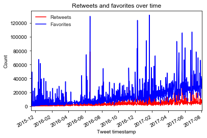

```python
time_df['retweet_count'].plot(color = 'red', label='Retweets')
time_df['favorite_count'].plot(color = 'blue', label='Favorites')
plt.style.use('seaborn-darkgrid')
plt.legend(loc='upper left')
plt.xlabel('Tweet timestamp')
plt.ylabel('Count')
plt.title('Retweets and favorites over time')
plt.savefig('retweets_favorites.png')
plt.show()
```

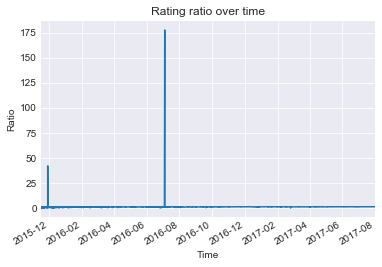

```python
time_df['rating_ratio'].plot()
plt.style.use('seaborn-darkgrid')
plt.xlabel('Time')
plt.ylabel('Ratio')
plt.title('Rating ratio over time')
plt.savefig('ratio.png')
plt.show()
```

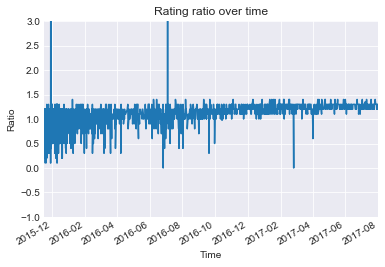

```python
# Limit y axis to zoom in on data and ignore outliers
time_df['rating_ratio'].plot()
plt.ylim(-1, 3)
plt.style.use('seaborn-darkgrid')
plt.xlabel('Time')
plt.ylabel('Ratio')
plt.title('Rating ratio over time')
plt.savefig('ratio_zoom.png')
plt.show()
```